# Alyssa Bockman and Thalia Koutsougeras

Milestone 1

**Final Project** Disease Prevalence Across the States

Main Data from: https://think.cs.vt.edu/corgis/csv/health/

GitHub: https://tkoooo.github.io/Final-Portfolio/

## Project Plan

**Project Description and Goals:** This dataset will allow us to examine the prevalence of various diseases across all 50 states over the last century. We plan to research factors such a vaccination rates and to try and understand the peaks and valleys in the dataset. We also want to examine what regions and states have been most and least affected and compare it with factors like weather patterns and population density.

**Question**: How does location correlate with probability of catching any 1 disease within the 20th century. Furhtermore, do other factors such as income and population density show this same correlation - this could potentially explain why certain states showed a higher incidence for disease when compared to others

**Collaboration Plan:** Our collaboration plan is to continue meeting at least once a week over zoom on Wednesday nights.

Milestone 2 requirements (5 Points) Professionalism: You have used both code comments and markdown cells to professionally and clearly document your work including having a clear and clean notebook; linking to resources and documents; and doing so with code that is reasonable and efficient. Your notebook is correct and contains the required links. In addition, you have written code that is interpretable – it contains comments where needed to understand, variable names are reasonable, and code that is reasonable and efficient. You have followed directions to turn in the file, clearly labeling everything. You have cited all sources and how you used them in the written portion of your answers.

(5 Points) Extraction, Transform, and Load (ETL): You are now using more than one dataset and they are both loaded correctly using web scraping other techniques. The data is discussed in terms of what it is and how it could be used to answer the question of study. Where the data comes from and how it is collected is clearly documented with links and other relevant details. The data is imported and tidy according to the principles discussed in class. Dtypes are set properly and displayed within the notebook, NaN’s and other techniques are used following best practices discussed in class.

(5 Points) Exploratory Data Analysis (EDA): At least 5 graphs and/or summary statistics/tables including cross-tabulations, groups, measures of central tendency, and/or any of the other EDA techniques discussed showing that you have started to investigate your data and have an understanding of what is in your dataset. Each of these pieces of analysis should have a corresponding markdown cell that clearly explains what is being shown and why. (5 Points) Model Questions: You have identified at least two plausible models that you could build using your data and the graphs in your EDA section support continuing the investigation. You have clearly identified independent and dependent variables and appropriate test/prediction methodology for each question.

## Data Selection and Filtering

Data from: https://think.cs.vt.edu/corgis/csv/health/

```python
from google.colab import drive
drive.mount('/content/drive')
%cd /content/drive/My Drive/cmps3160
```

```
/content/drive/My Drive/cmps3160
```

```python
%cd /content/drive/My Drive/cmps3160/finalProject
```

```
/content/drive/My Drive/cmps3160/finalProject
```

### Preliminary Data Analysis - National Incidence and Case Numbers

```python
import pandas as pd
import matplotlib.pyplot as plt
#import pandas and matplotlib for graphing

df = pd.read_csv("../finalProject/health.csv", sep=",")
#read dataset into variable df

#check what values are missing
df[df.isnull().any(axis=1)]
```

|  | disease | increase | loc | number | population | year |
| --- | --- | --- | --- | --- | --- | --- |

Lucky for us, no data is missing and we can proceed onto analysis!

```python
#Data types analysis
```

```python
measles = df[df['disease'] == "MEASLES"]
measles['increase'].min()
```

```
0.0
```

```python
#in order to visualize the case prevelance across the entire country, we will drop the
#location and increase columns and then create seperate dataframes for each disease
#df = df.drop(columns=['loc', 'increase'])
measles = df[df['disease'] == "MEASLES"]
polio = df[df['disease'] == "POLIO"]
smallpox = df[df['disease'] == "SMALLPOX"]
pertussis = df[df['disease'] == "PERTUSSIS"]
hepa = df[df['disease'] == "HEPATITIS A"]
rubella = df[df['disease'] == "RUBELLA"]
mumps = df[df['disease'] == "MUMPS"]
```

Now that we have datasets that hold only the specific disease information for each illness, we can begin to perform some basic analysis.

We will extract data to get numbers in the country instead of by state and perform further analysis to calculate the incidence for each disease each year.

In public health there are 2 main ways to measure how disease affects a population: incidence and prevalence.

Incidence refers to the number of people that develop/are diagnosed within a time period divided by the total sample size, while prevalence refers to the number of people being actively affected by the disease (whether they were diagnosed within the time period or not) divided by the total smaple size.

Because this data set provides us with the number of new cases per year and nothing about the amount of time people were sick, we will be focusing on calculating the incidence for each disease throughout the entire country.

This will provide 1 helpful dataset for each disease that will allow us to graph both the case numbers in the country as well as the proportion of people affected over the years.

#### Measles

```python
#Measles

#grab the case numbers country wide for each year
measles_country = measles.groupby(by='year')['number'].sum()

#grab the population size country side for each year
measles_population = measles.groupby(by='year')['population'].sum()

#transform the number and population series in to dataframes for future operations
measles_country = measles_country.to_frame()
measles_population = measles_population.to_frame()

#join the number and population dataframes to allow us to create a new incidence column
measles_incidence = measles_population.join(other=measles_country, on='year')

#create a new column called incidence that shows the proportion of the population affected each year
measles_incidence["incidence"] = measles_incidence["number"]/measles_incidence["population"]

#change the index to regular numbers rather than the year
measles_incidence.reset_index(inplace =True)

measles_incidence.head()

#measles_incidence.plot.line(x = 'year', y = 'number', figsize=(20,10))
```

|  | year | population | number | incidence |
| --- | --- | --- | --- | --- |
| 0 | 1928 | 117976000 | 483337 | 0.004097 |
| 1 | 1929 | 117256000 | 339061 | 0.002892 |
| 2 | 1930 | 118550000 | 384597 | 0.003244 |
| 3 | 1931 | 119505000 | 438435 | 0.003669 |
| 4 | 1932 | 122739000 | 390114 | 0.003178 |

#### Polio

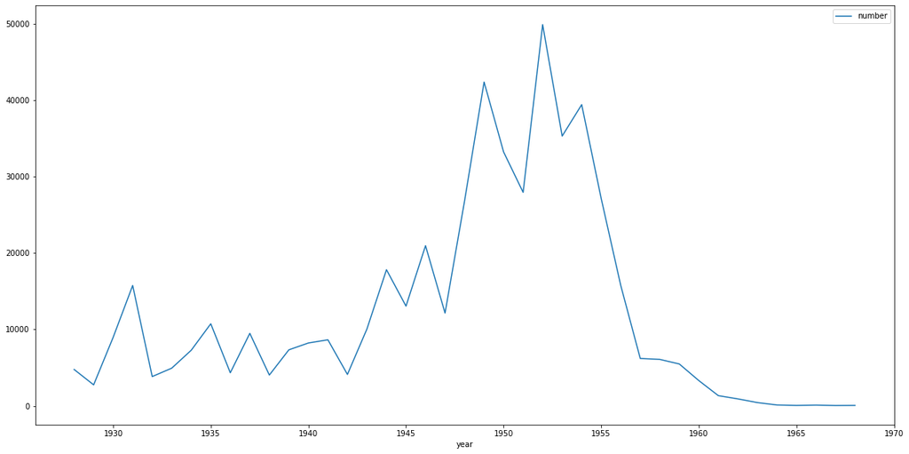

```python
#Polio

#grab the case numbers country wide for each year
polio_country = polio.groupby(by='year')['number'].sum()

#grab the population size country side for each year
polio_population = polio.groupby(by='year')['population'].sum()

#transform the number and population series in to dataframes for future operations
polio_country = polio_country.to_frame()
polio_population = polio_population.to_frame()

#join the number and population dataframes to allow us to create a new incidence column
polio_incidence = polio_population.join(other=polio_country, on='year')

#create a new column called incidence that shows the proportion of the population affected each year
polio_incidence["incidence"] = polio_incidence["number"]/polio_incidence["population"]

#change the index to regular numbers rather than the year
polio_incidence.reset_index(inplace = True)

polio_incidence.head()

polio_incidence.plot.line(x = 'year', y = 'number', figsize=(20,10))
```

#### Smallpox

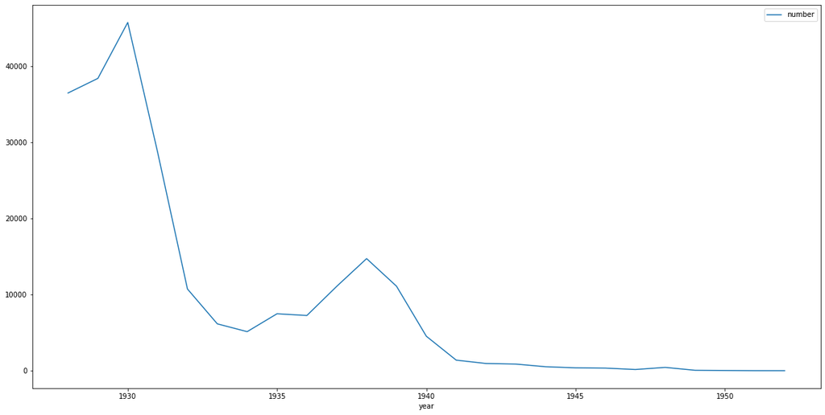

```python
#Smallpox

#grab the case numbers country wide for each year
smallpox_country = smallpox.groupby(by='year')['number'].sum()

#grab the population size country side for each year
smallpox_population = smallpox.groupby(by='year')['population'].sum()

#transform the number and population series in to dataframes for future operations
smallpox_country = smallpox_country.to_frame()
smallpox_population = smallpox_population.to_frame()

#join the number and population dataframes to allow us to create a new incidence column
smallpox_incidence = smallpox_population.join(other=smallpox_country, on='year')

#create a new column called incidence that shows the proportion of the population affected each year
smallpox_incidence["incidence"] = smallpox_incidence["number"]/smallpox_incidence["population"]

#change the index to regular numbers rather than the year
smallpox_incidence.reset_index(inplace = True)

smallpox_incidence.head()

smallpox_incidence.plot.line(x = 'year', y = 'number', figsize=(20,10))
```

#### Pertussis

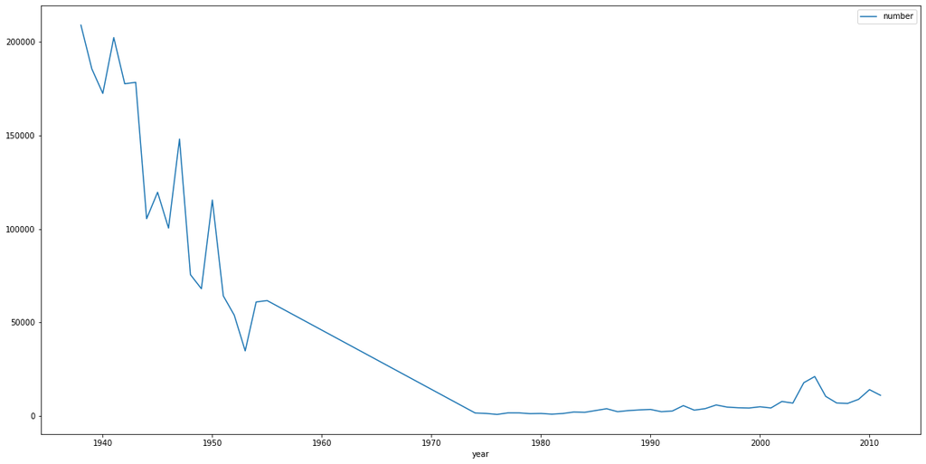

```python
#Pertussis

#grab the case numbers country wide for each year
pertussis_country = pertussis.groupby(by='year')['number'].sum()

#grab the population size country side for each year
pertussis_population = pertussis.groupby(by='year')['population'].sum()

#transform the number and population series in to dataframes for future operations
pertussis_country = pertussis_country.to_frame()
pertussis_population = pertussis_population.to_frame()

#join the number and population dataframes to allow us to create a new incidence column
pertussis_incidence = pertussis_population.join(other=pertussis_country, on='year')

#create a new column called incidence that shows the proportion of the population affected each year
pertussis_incidence["incidence"] = pertussis_incidence["number"]/pertussis_incidence["population"]

#change the index to regular numbers rather than the year
pertussis_incidence.reset_index(inplace = True)

pertussis_incidence.head()

pertussis_incidence.plot.line(x = 'year', y = 'number', figsize=(20,10))
```

#### Hepatitis A

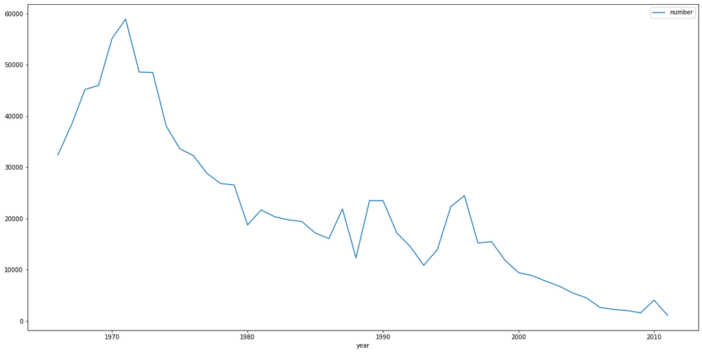

```python
#Hepatitis A

#grab the case numbers country wide for each year
hepa_country = hepa.groupby(by='year')['number'].sum()

#grab the population size country side for each year
hepa_population = hepa.groupby(by='year')['population'].sum()

#transform the number and population series in to dataframes for future operations
hepa_country = hepa_country.to_frame()
hepa_population = hepa_population.to_frame()

#join the number and population dataframes to allow us to create a new incidence column
hepa_incidence = hepa_population.join(other=hepa_country, on='year')

#create a new column called incidence that shows the proportion of the population affected each year
hepa_incidence["incidence"] = hepa_incidence["number"]/hepa_incidence["population"]

#change the index to regular numbers rather than the year
hepa_incidence.reset_index(inplace = True)

hepa_incidence.head()

hepa_incidence.plot.line(x = 'year', y = 'number', figsize=(20,10))
```

#### Rubella

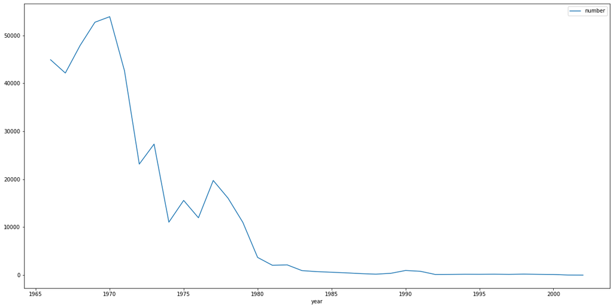

```python
#Rubella

#grab the case numbers country wide for each year
rubella_country = rubella.groupby(by='year')['number'].sum()

#grab the population size country side for each year
rubella_population = rubella.groupby(by='year')['population'].sum()

#transform the number and population series in to dataframes for future operations
rubella_country = rubella_country.to_frame()
rubella_population = rubella_population.to_frame()

#join the number and population dataframes to allow us to create a new incidence column
rubella_incidence = rubella_population.join(other=rubella_country, on='year')

#create a new column called incidence that shows the proportion of the population affected each year
rubella_incidence["incidence"] = rubella_incidence["number"]/rubella_incidence["population"]

#change the index to regular numbers rather than the year
rubella_incidence.reset_index(inplace = True)

rubella_incidence.head()

rubella_incidence.plot.line(x = 'year', y = 'number', figsize=(20,10))
```

#### Mumps

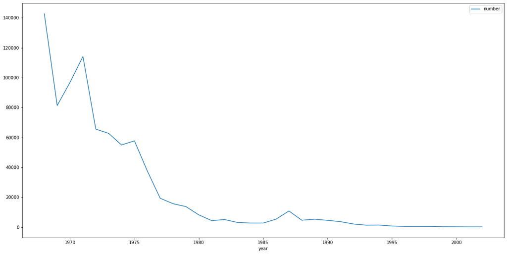

```python
#Mumps

#grab the case numbers country wide for each year
mumps_country = mumps.groupby(by='year')['number'].sum()

#grab the population size country side for each year
mumps_population = mumps.groupby(by='year')['population'].sum()

#transform the number and population series in to dataframes for future operations
mumps_country = mumps_country.to_frame()
mumps_population = mumps_population.to_frame()

#join the number and population dataframes to allow us to create a new incidence column
mumps_incidence = mumps_population.join(other=mumps_country, on='year')

#create a new column called incidence that shows the proportion of the population affected each year
mumps_incidence["incidence"] = mumps_incidence["number"]/mumps_incidence["population"]

#change the index to regular numbers rather than the year
mumps_incidence.reset_index(inplace = True)

mumps_incidence.head()

mumps_incidence.plot.line(x = 'year', y = 'number', figsize=(20,10))
```

#### National Case Numbers and National Incidence

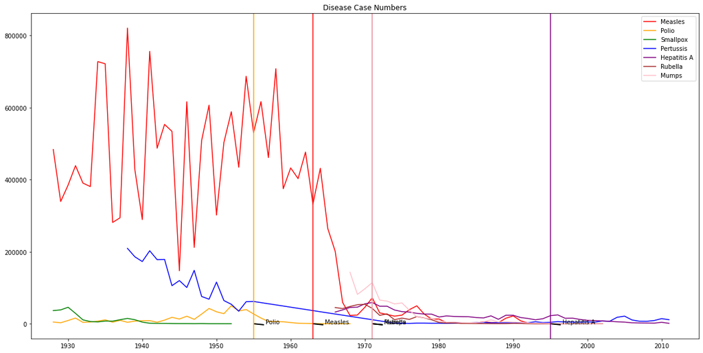

```python
vaccine_data = [("Measles", 1963), ("Polio", 1955), ("Smallpox", 1798), ("Pertussis", 1915), ("Hepatitis A", 1995), ("Rubella", 1971), ("Mumps", 1971)]
vaccine_df = pd.DataFrame(vaccine_data, columns=['Disease', 'Year'])
vaccine_df = vaccine_df.sort_values('Year') #We want this sorted by year because we run into annotation issues later if not since Rubella and Mumps are in the same year
vaccine_df.reset_index(inplace=True)
vaccine_df.drop(columns=['index'], inplace=True) #Cleaning up data


fig = plt.figure(figsize=(20,10));

colors = ['red', 'orange', 'green', 'blue', 'purple', 'brown', 'pink']; #colors for legend
colors_2 = ['green', 'blue', 'orange', 'red', 'brown', 'pink', 'purple']; #colors matching vaccine dataset
i = 0

# Plotting each disease over time
for frame in [measles_incidence, polio_incidence, smallpox_incidence, pertussis_incidence, hepa_incidence, rubella_incidence, mumps_incidence]:
    plt.plot(frame['year'], frame['number'], color=f'{colors[i]}');
    i += 1

for i in range(0, len(vaccine_df)): #this plots vertical lines where the vaccines came out
  if vaccine_df.iloc[i].Year < 1930: #this removes the whitespace that appears before the graph because of the vaccines that came out before 1930
    continue
  plt.axvline(x=vaccine_df.iloc[i].Year, color = f'{colors_2[i]}'); #this matches the color of the vertical line to the color of the disease in the legend
  plt.annotate(s = f'{vaccine_df.iloc[i].Disease}', xy=(vaccine_df.iloc[i].Year, 0.006 - i*0.0002), xytext=(20, 0.0055), textcoords='offset points', annotation_clip=True, arrowprops={'width': 1, 'headwidth': 1, 'headlength': 1, 'shrink':0.05});

plt.legend(["Measles", "Polio", "Smallpox", "Pertussis", "Hepatitis A", "Rubella", "Mumps"]);
plt.title("Disease Case Numbers");
plt.xlim(1925, 2015); #we have to cut off the limits because 2 of the vaccines appeared way before 1930 and make the graph hard to read
```

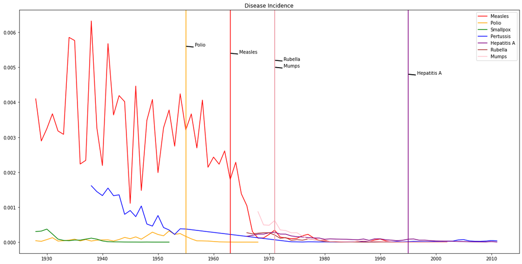

```python
fig = plt.figure(figsize=(20,10));

colors = ['red', 'orange', 'green', 'blue', 'purple', 'brown', 'pink']; #colors for legend
colors_2 = ['green', 'blue', 'orange', 'red', 'brown', 'pink', 'purple']; #colors matching vaccine dataset
i = 0

# Plotting each disease over time
for frame in [measles_incidence, polio_incidence, smallpox_incidence, pertussis_incidence, hepa_incidence, rubella_incidence, mumps_incidence]:
    plt.plot(frame['year'], frame['incidence'], color=f'{colors[i]}');
    i += 1

for i in range(0, len(vaccine_df)): #this plots vertical lines where the vaccines came out
  if vaccine_df.iloc[i].Year < 1930: #this removes the whitespace that appears before the graph because of the vaccines that came out before 1930
    continue
  plt.axvline(x=vaccine_df.iloc[i].Year, color = f'{colors_2[i]}'); #this matches the color of the vertical line to the color of the disease in the legend
  plt.annotate(s = f'{vaccine_df.iloc[i].Disease}', xy=(vaccine_df.iloc[i].Year, 0.006 - i*0.0002), xytext=(20, 0.0055), textcoords='offset points', annotation_clip=True, arrowprops={'width': 1, 'headwidth': 1, 'headlength': 1, 'shrink':0.05});

plt.legend(["Measles", "Polio", "Smallpox", "Pertussis", "Hepatitis A", "Rubella", "Mumps"]);
plt.title("Disease Incidence");
plt.xlim(1925, 2015); #we have to cut off the limits because 2 of the vaccines appeared way before 1930 and make the graph hard to read
```

It is worth nothing that the vaccines for Pertussis and Smallpox were released prior to the first collection year of this dataset, so they are nto marked

All of the vaccines seem to have been released after the peak of the disease which may speak to the either the speed and efficiency of US Public Health, the perceived need, or the state of science at the time.

### Preliminary Data Analysis - State to State Incidence

Now that we have a solid idea of what the trends look like on a national scale, we can zoom back in to look at individual states to try and see how they compare.

#### Preparing a Dataset for Graphing

Cartographic Boundary Files - Shapefile of the United States: https://www.sciencebase.gov/catalog/item/52c78623e4b060b9ebca5be5

We originally got our data from the US Census, but there was too much data (each state had multiple coordinates for its regions). We found this dataset from sciencebase.gov, which is a U.S. Geological Survey Trusted Digital Repository. Their files are simpler and contain single coordinates for each state. We want only one row of data for each state so that we can easily join our data with our other datasets.

We followed these tutorials to implement our code:

https://mohammadimranhasan.com/geospatial-data-mapping-with-python/

https://towardsdatascience.com/lets-make-a-map-using-geopandas-pandas-and-matplotlib-to-make-a-chloropleth-map-dddc31c1983d

First, we need to install geopandas in order to create maps and import our coordinates file.

```python
!pip install geopandas
#!pip install --upgrade pyshp
#!pip install --upgrade shapely
#!pip install --upgrade descartes
```

We need to read in the zip file.

```python
import geopandas
states = geopandas.read_file("tl_2012_us_state.zip")

states.head()
```

|  | OBJECTID | REGION | DIVISION | STATEFP | STATENS | GEOID | STUSPS | NAME | LSAD | MTFCC | FUNCSTAT | ALAND | AWATER | INTPTLAT | INTPTLON | Shape_Leng | Shape_Area | geometry |
| --- | --- | --- | --- | --- | --- | --- | --- | --- | --- | --- | --- | --- | --- | --- | --- | --- | --- | --- |
| 0 | 1 | 4 | 9 | 15 | 01779782 | 15 | HI | Hawaii | 00 | G4000 | A | 1.663425e+10 | 1.167874e+10 | +19.8097670 | -155.5061027 | 2.419034e+06 | 3.268482e+10 | MULTIPOLYGON (((-17361760.204 2164544.588, -17... |
| 1 | 2 | 3 | 7 | 05 | 00068085 | 05 | AR | Arkansas | 00 | G4000 | A | 1.347726e+11 | 2.959210e+09 | +34.8955256 | -092.4446262 | 2.656648e+06 | 2.053261e+11 | POLYGON ((-10515267.713 4101325.818, -10515269... |
| 2 | 3 | 4 | 8 | 35 | 00897535 | 35 | NM | New Mexico | 00 | G4000 | A | 3.141611e+11 | 7.564385e+08 | +34.4346843 | -106.1316181 | 2.900368e+06 | 4.643927e+11 | POLYGON ((-12138963.727 4106855.170, -12138964... |
| 3 | 4 | 4 | 8 | 30 | 00767982 | 30 | MT | Montana | 00 | G4000 | A | 3.769636e+11 | 3.868565e+09 | +47.0511771 | -109.6348174 | 4.607246e+06 | 8.201836e+11 | POLYGON ((-12727480.235 5886876.586, -12727567... |
| 4 | 5 | 1 | 2 | 36 | 01779796 | 36 | NY | New York | 00 | G4000 | A | 1.220579e+11 | 1.923885e+10 | +42.9133974 | -075.5962723 | 3.212630e+06 | 2.637702e+11 | MULTIPOLYGON (((-8866092.533 5160809.769, -886... |

**Cleaning up the dataset**

There are some columns we don't need, and we can rename the columns to make them look neater.

```python
states.columns.unique() #grabbing column names
```

```
Index(['OBJECTID', 'REGION', 'DIVISION', 'STATEFP', 'STATENS', 'GEOID',
       'STUSPS', 'NAME', 'LSAD', 'MTFCC', 'FUNCSTAT', 'ALAND', 'AWATER',
       'INTPTLAT', 'INTPTLON', 'Shape_Leng', 'Shape_Area', 'geometry'],
      dtype='object')
```

```python
states.drop(columns=['OBJECTID', 'REGION', 'DIVISION', 'STATEFP', 'STATENS', 'GEOID',
       'STUSPS', 'LSAD', 'MTFCC', 'FUNCSTAT', 'ALAND', 'AWATER',
       'INTPTLAT', 'INTPTLON', 'Shape_Leng', 'Shape_Area'], inplace=True) #dropping unnecessary columns
states.rename(columns={'NAME':'State', 'geometry': 'Geometry'}, inplace=True) #renaming the columns to make them look prettier
states['State'] = states['State'].str.upper() #in order to join with previous datasets we want this to match
states.head()
```

|  | State | Geometry |
| --- | --- | --- |
| 0 | HAWAII | MULTIPOLYGON (((-17361760.204 2164544.588, -17... |
| 1 | ARKANSAS | POLYGON ((-10515267.713 4101325.818, -10515269... |
| 2 | NEW MEXICO | POLYGON ((-12138963.727 4106855.170, -12138964... |
| 3 | MONTANA | POLYGON ((-12727480.235 5886876.586, -12727567... |
| 4 | NEW YORK | MULTIPOLYGON (((-8866092.533 5160809.769, -886... |

```python
states.shape[0]
```

```
56
```

From the code above, we see that there are 56 rows, even though we know there are 50 states. By looking at the data, we see acquired regions of the US included, such as Puerto Rico and Guam. We need to keep this in mind for joining our data.

We need to check for NaN values.

```python
states.isnull().sum()
```

```
State       0
Geometry    0
dtype: int64
```

Perfect! We have no NaN values.

Just to test that we are using GeoPandas correctly, here is a simple map of the US.

```
(0.0, 12000000.0)
```

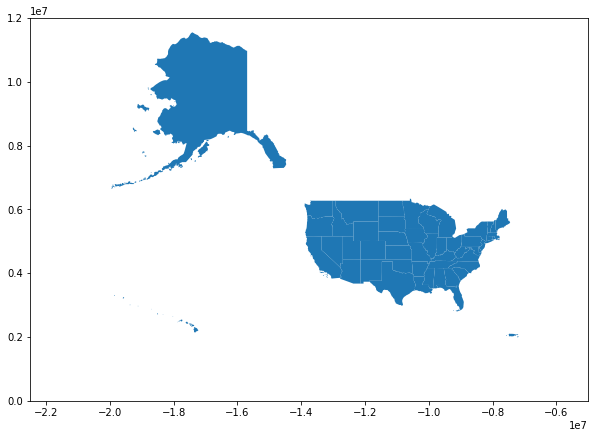

```python
states = geopandas.GeoDataFrame(states, geometry='Geometry') #turning the dataframe into a geodataframe object
states.plot(figsize=(10, 10))
plt.xlim(-2.25e7, -0.5e7)
plt.ylim(0.0, 1.2e7)
```

Great! We are good to move on with analysis. This work will be reffered to later in the seperate sections for national incidence of each disease

#### Measles

Great! We are good to move on with analysis.

We will now make a dataset that is usable for making a visual map.

```python
from matplotlib import legend
#for clean data, we will continue to do do seperate operations for each disease type

#create a dictionary of dataframs for every state
states_measles = dict()
for k, v in measles.groupby('loc'):
  states_measles[k] = v

#create an incidence column for every dataframe in the dictionary
for i in states_measles:
  states_measles[i]['incidence'] = states_measles[i]['number']/states_measles[i]['population']
  #set the index to year for easy combining later
  states_measles[i].set_index('year', inplace = True)

#create new dataframe of all of the incidences by state for every year
states_measles_incidence = pd.DataFrame()

#enter the incidence columns from the state datasets into the incidence dataset
for i in states_measles:
  states_measles_incidence[i] = states_measles[i]['incidence']

states_measles_incidence

states_measles
```

[output not shown]

[output cut: 1113 more lines]

We now have a dataframe called incidence that has the incidence for each state of each year. What is interesting now though is that we have several states that have NaN numbers for their entries. This is because while every row in the initial dataset was entirely filled out, not every state had an entry for every year. We don't want to drop every NaN value because there are 50 columns, so that could result in losing almost if not all of our data. Instead, we will try to work around them.

We are now ready to pull on the earlier dataframe we made earlier to create a heat map representation of the data

```python
map_measles_df = states_measles_incidence.T #transpose to get states in a column
map_measles_df.reset_index(inplace=True)
map_measles_df.rename(columns={'index':'State'}, inplace=True)
map_measles_df = pd.merge(map_measles_df, states, on="State", how='left') #we want to use the keys of the incidence values because we know those are 50 states, not including Guam, etc.
map_measles_df.head()
```

|  | State | 1928 | 1929 | 1930 | 1931 | 1932 | 1933 | 1934 | 1935 | 1936 | ... | 1987 | 1988 | 1989 | 1990 | 1991 | 1993 | 1997 | 1998 | 2002 | Geometry |
| --- | --- | --- | --- | --- | --- | --- | --- | --- | --- | --- | --- | --- | --- | --- | --- | --- | --- | --- | --- | --- | --- |
| 0 | ALABAMA | 0.003350 | 0.001119 | 0.001570 | 0.003373 | 0.000102 | 0.000652 | 0.005903 | 0.002653 | 0.000208 | ... | 9.940743e-07 | 2.481253e-07 | 0.000015 | 0.000007 | 2.439527e-07 | 2.372928e-07 | 0.000001 | 0.000000e+00 | 0.000002 | POLYGON ((-9841333.855 3579579.495, -9841349.6... |
| 1 | ALASKA | NaN | NaN | NaN | NaN | NaN | NaN | NaN | NaN | NaN | ... | NaN | 1.827622e-06 | 0.000000 | 0.000049 | 1.753792e-06 | NaN | 0.000002 | 2.580928e-05 | NaN | MULTIPOLYGON (((-15108567.654 8339788.089, -15... |
| 2 | ARIZONA | 0.002007 | 0.000549 | 0.004664 | 0.004977 | 0.000202 | 0.002960 | 0.002388 | 0.001350 | 0.005255 | ... | 9.900478e-06 | 8.282294e-07 | 0.000040 | 0.000077 | 9.027138e-05 | 7.379275e-07 | 0.000002 | 2.047778e-06 | NaN | POLYGON ((-12761162.105 4147165.875, -12761214... |
| 3 | ARKANSAS | 0.004818 | 0.000672 | 0.000535 | 0.000459 | 0.000054 | 0.002933 | 0.003846 | 0.000803 | 0.000057 | ... | NaN | NaN | 0.000002 | 0.000017 | NaN | NaN | 0.000001 | NaN | NaN | POLYGON ((-10515267.713 4101325.818, -10515269... |
| 4 | CALIFORNIA | 0.000692 | 0.000728 | 0.007602 | 0.004775 | 0.002141 | 0.004453 | 0.004233 | 0.004664 | 0.007735 | ... | 2.719200e-05 | 2.515558e-05 | 0.000074 | 0.000320 | 6.442247e-05 | 2.014393e-06 | 0.000001 | 1.212574e-07 | 0.000000 | MULTIPOLYGON (((-13060108.516 3854208.959, -13... |

5 rows × 68 columns

Here, we take in user input to plot the map for a certain year of their choosing:

```
What year would you like to display (between 1928 and 2002? 1940
```

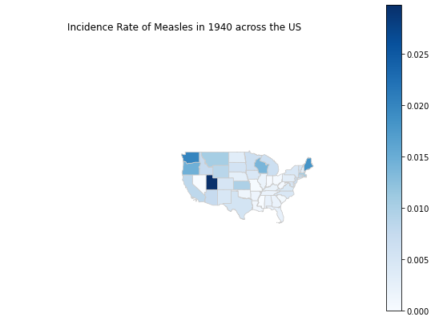

```python
sel = str(input("What year would you like to display (between 1928 and 2002? ")) #take in input
sel = int(sel) #turn into an integer for later

map_measles_df = geopandas.GeoDataFrame(map_measles_df, geometry='Geometry') #turning the dataframe into a geodataframe object to be used with geopandas to plot

#Here we are trying to find the min and max values to use for our scalebar
#We don't want to do this for each year because looking at the graph over time would be misleading if you kept changing the scalebars
map_measles_df.columns.unique()
merged_cols = map_measles_df.columns.unique()

merged_cols = merged_cols[1:-1] #only grabbing the years
vmin = map_measles_df[merged_cols].min().min()
vmax = map_measles_df[merged_cols].max().max()

#Plotting
fig, ax = plt.subplots(1, figsize=(10,7))
map_measles_df.plot(column=sel, figsize=(10, 7), cmap='Blues', linewidth=0.8, ax=ax, edgecolor='0.8')
plt.xlim(-2.25e7, -0.5e7) #resetting axes
plt.ylim(0.5, 1.2e7)
ax.axis('off') #remove axis because it means nothing for us

ax.set_title(f'Incidence Rate of Measles in {sel} across the US')

sm = plt.cm.ScalarMappable(cmap='Blues', norm=plt.Normalize(vmin=vmin, vmax=vmax)) #for color scalebar
sm._A = []
cbar = fig.colorbar(sm)
```

Now that we hve this incidence for each state, we can compare them to the national incidences to see if there are any states that experienced a higher rate than nationally. We can also just compare ampng the states to see which states experienced the highest and lowest incidence rate over the years.

#### Polio

```python
from matplotlib import legend
#for clean data, we will continue to do do seperate operations for each disease type

#create a dictionary of dataframs for every state
states_polio = dict()
for k, v in polio.groupby('loc'):
  states_polio[k] = v

#create an incidence column for every dataframe in the dictionary
for i in states_polio:
  states_polio[i]['incidence'] = states_polio[i]['number']/states_polio[i]['population']
  #set the index to year for easy combining later
  states_polio[i].set_index('year', inplace = True)

#create new dataframe of all of the incidences by state for every year
states_polio_incidence = pd.DataFrame()

#enter the incidence columns from the state datasets into the incidence dataset
for i in states_polio:
  states_polio_incidence[i] = states_polio[i]['incidence']

states_polio_incidence.head()
```

| year | ALABAMA | ALASKA | ARIZONA | ARKANSAS | CALIFORNIA | COLORADO | CONNECTICUT | DELAWARE | DISTRICT OF COLUMBIA | FLORIDA | ... | SOUTH DAKOTA | TENNESSEE | TEXAS | UTAH | VERMONT | VIRGINIA | WASHINGTON | WEST VIRGINIA | WISCONSIN | WYOMING |
| --- | --- | --- | --- | --- | --- | --- | --- | --- | --- | --- | --- | --- | --- | --- | --- | --- | --- | --- | --- | --- | --- |
| 1928 | 0.000023 | NaN | 0.000026 | 0.000005 | 0.000051 | 0.000070 | 0.000046 | 0.000034 | 0.000069 | 0.000015 | ... | 0.000064 | 0.000013 | 0.000007 | 0.000018 | 0.000073 | 0.000006 | 0.000208 | 0.000114 | 0.000017 | 0.000027 |
| 1929 | 0.000022 | NaN | 0.000021 | 0.000002 | 0.000028 | 0.000013 | 0.000013 | 0.000021 | 0.000012 | 0.000024 | ... | 0.000004 | 0.000036 | 0.000003 | 0.000008 | 0.000053 | 0.000099 | 0.000017 | 0.000034 | 0.000007 | 0.000013 |
| 1930 | 0.000025 | NaN | 0.000074 | 0.000042 | 0.000307 | 0.000063 | 0.000046 | 0.000025 | 0.000018 | 0.000008 | ... | 0.000202 | 0.000023 | 0.000022 | 0.000006 | 0.000008 | 0.000005 | 0.000030 | 0.000024 | 0.000061 | 0.000243 |
| 1931 | 0.000020 | NaN | 0.000026 | 0.000009 | 0.000043 | 0.000009 | 0.000700 | 0.000021 | 0.000030 | 0.000011 | ... | 0.000042 | 0.000018 | 0.000006 | 0.000010 | 0.000248 | 0.000010 | 0.000054 | 0.000047 | 0.000246 | 0.000026 |
| 1932 | 0.000013 | NaN | 0.000016 | 0.000008 | 0.000029 | 0.000008 | 0.000020 | 0.000045 | 0.000066 | 0.000005 | ... | 0.000022 | 0.000020 | 0.000012 | 0.000006 | 0.000006 | 0.000022 | 0.000047 | 0.000025 | 0.000019 | 0.000026 |

5 rows × 51 columns

```python
map_polio_df = states_polio_incidence.T #transpose to get states in a column
map_polio_df.reset_index(inplace=True)
map_polio_df.rename(columns={'index':'State'}, inplace=True)
map_polio_df = pd.merge(map_polio_df, states, on="State", how='left') #we want to use the keys of the incidence values because we know those are 50 states, not including Guam, etc.
map_polio_df.head()
```

|  | State | 1928 | 1929 | 1930 | 1931 | 1932 | 1933 | 1934 | 1935 | 1936 | ... | 1958 | 1959 | 1960 | 1961 | 1962 | 1963 | 1964 | 1966 | 1968 | Geometry |
| --- | --- | --- | --- | --- | --- | --- | --- | --- | --- | --- | --- | --- | --- | --- | --- | --- | --- | --- | --- | --- | --- |
| 0 | ALABAMA | 0.000023 | 0.000022 | 0.000025 | 0.000020 | 0.000013 | 0.000011 | 0.000019 | 0.000022 | 0.000153 | ... | 0.000020 | 0.000048 | 0.000007 | 0.000003 | 0.000007 | 0.000016 | 5.891016e-07 | 0.000000e+00 | 2.901915e-07 | POLYGON ((-9841333.855 3579579.495, -9841349.6... |
| 1 | ALASKA | NaN | NaN | NaN | NaN | NaN | NaN | NaN | NaN | NaN | ... | 0.000009 | 0.000089 | 0.000009 | NaN | NaN | NaN | NaN | NaN | NaN | MULTIPOLYGON (((-15108567.654 8339788.089, -15... |
| 2 | ARIZONA | 0.000026 | 0.000021 | 0.000074 | 0.000026 | 0.000016 | 0.000038 | 0.000257 | 0.000048 | 0.000020 | ... | 0.000028 | 0.000049 | 0.000007 | 0.000006 | 0.000004 | 0.000002 | NaN | NaN | 5.945303e-07 | POLYGON ((-12761162.105 4147165.875, -12761214... |
| 3 | ARKANSAS | 0.000005 | 0.000002 | 0.000042 | 0.000009 | 0.000008 | 0.000007 | 0.000007 | 0.000015 | 0.000030 | ... | 0.000024 | 0.000110 | 0.000023 | 0.000014 | 0.000014 | 0.000003 | NaN | 5.265929e-07 | 5.257624e-07 | POLYGON ((-10515267.713 4101325.818, -10515269... |
| 4 | CALIFORNIA | 0.000051 | 0.000028 | 0.000307 | 0.000043 | 0.000029 | 0.000025 | 0.000540 | 0.000126 | 0.000059 | ... | 0.000021 | 0.000022 | 0.000026 | 0.000006 | 0.000005 | 0.000001 | 1.101868e-07 | 1.590837e-07 | 5.671857e-07 | MULTIPOLYGON (((-13060108.516 3854208.959, -13... |

5 rows × 41 columns

```
What year would you like to display (between 1928 and 1968? 1940
```

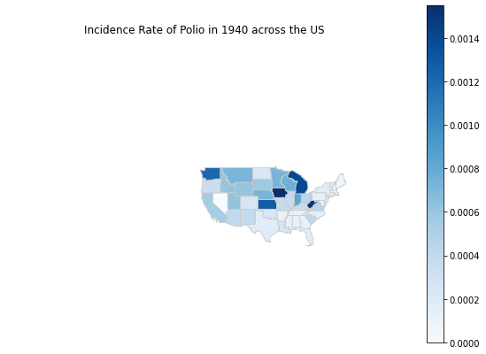

```python
sel = str(input("What year would you like to display (between 1928 and 1968? ")) #take in input
sel = int(sel) #turn into an integer for later

map_polio_df = geopandas.GeoDataFrame(map_polio_df, geometry='Geometry') #turning the dataframe into a geodataframe object to be used with geopandas to plot

#Here we are trying to find the min and max values to use for our scalebar
#We don't want to do this for each year because looking at the graph over time would be misleading if you kept changing the scalebars
map_polio_df.columns.unique()
merged_cols = map_polio_df.columns.unique()

merged_cols = merged_cols[1:-1] #only grabbing the years
vmin = map_polio_df[merged_cols].min().min()
vmax = map_polio_df[merged_cols].max().max()

#Plotting
fig, ax = plt.subplots(1, figsize=(10,7))
map_polio_df.plot(column=sel, figsize=(10, 7), cmap='Blues', linewidth=0.8, ax=ax, edgecolor='0.8')
plt.xlim(-2.25e7, -0.5e7) #resetting axes
plt.ylim(0.5, 1.2e7)
ax.axis('off') #remove axis because it means nothing for us

ax.set_title(f'Incidence Rate of Polio in {sel} across the US')

sm = plt.cm.ScalarMappable(cmap='Blues', norm=plt.Normalize(vmin=vmin, vmax=vmax)) #for color scalebar
sm._A = []
cbar = fig.colorbar(sm)
```

#### Pertussis

```python
from matplotlib import legend
#for clean data, we will continue to do do seperate operations for each disease type

#create a dictionary of dataframs for every state
states_pertussis = dict()
for k, v in pertussis.groupby('loc'):
  states_pertussis[k] = v

#create an incidence column for every dataframe in the dictionary
for i in states_pertussis:
  states_pertussis[i]['incidence'] = states_pertussis[i]['number']/states_pertussis[i]['population']
  #set the index to year for easy combining later
  states_pertussis[i].set_index('year', inplace = True)

#create new dataframe of all of the incidences by state for every year
states_pertussis_incidence = pd.DataFrame()

#enter the incidence columns from the state datasets into the incidence dataset
for i in states_pertussis:
  states_pertussis_incidence[i] = states_pertussis[i]['incidence']

states_pertussis_incidence.head()
```

| year | ALABAMA | ALASKA | ARIZONA | ARKANSAS | CALIFORNIA | COLORADO | CONNECTICUT | DELAWARE | DISTRICT OF COLUMBIA | FLORIDA | ... | SOUTH DAKOTA | TENNESSEE | TEXAS | UTAH | VERMONT | VIRGINIA | WASHINGTON | WEST VIRGINIA | WISCONSIN | WYOMING |
| --- | --- | --- | --- | --- | --- | --- | --- | --- | --- | --- | --- | --- | --- | --- | --- | --- | --- | --- | --- | --- | --- |
| 1938 | 0.000661 | NaN | 0.003489 | 0.000804 | 0.002271 | 0.001477 | 0.002166 | 0.002292 | 0.000925 | 0.000458 | ... | 0.001160 | 0.000736 | 0.001573 | 0.004725 | 0.006935 | 0.001475 | 0.002615 | 0.001649 | 0.004112 | 0.002272 |
| 1939 | 0.000702 | NaN | 0.002138 | 0.000483 | 0.001245 | 0.001817 | 0.002378 | 0.002897 | 0.002271 | 0.000607 | ... | 0.000419 | 0.000785 | 0.000870 | 0.005843 | 0.008475 | 0.001275 | 0.000945 | 0.000809 | 0.003520 | 0.001907 |
| 1940 | 0.000434 | NaN | 0.001788 | 0.000415 | 0.001823 | 0.001107 | 0.001799 | 0.002264 | 0.001094 | 0.000349 | ... | 0.000284 | 0.000722 | 0.001278 | 0.007196 | 0.003793 | 0.001134 | 0.001164 | 0.000966 | 0.002249 | 0.000828 |
| 1941 | 0.000540 | NaN | 0.002400 | 0.000568 | 0.002622 | 0.004182 | 0.001591 | 0.001004 | 0.000937 | 0.000371 | ... | 0.000954 | 0.000865 | 0.001620 | 0.005018 | 0.001828 | 0.001467 | 0.002582 | 0.001201 | 0.002861 | 0.001534 |
| 1942 | 0.000558 | NaN | 0.002048 | 0.000464 | 0.001556 | 0.001626 | 0.002181 | 0.000545 | 0.001090 | 0.000381 | ... | 0.000411 | 0.000656 | 0.001155 | 0.002614 | 0.006061 | 0.000847 | 0.001579 | 0.000765 | 0.003420 | 0.001382 |

5 rows × 51 columns

```python
map_pertussis_df = states_pertussis_incidence.T #transpose to get states in a column
map_pertussis_df.reset_index(inplace=True)
map_pertussis_df.rename(columns={'index':'State'}, inplace=True)
map_pertussis_df = pd.merge(map_pertussis_df, states, on="State", how='left') #we want to use the keys of the incidence values because we know those are 50 states, not including Guam, etc.
map_pertussis_df.head()
```

|  | State | 1938 | 1939 | 1940 | 1941 | 1942 | 1943 | 1944 | 1945 | 1946 | ... | 2003 | 2004 | 2005 | 2006 | 2007 | 2008 | 2009 | 2010 | 2011 | Geometry |
| --- | --- | --- | --- | --- | --- | --- | --- | --- | --- | --- | --- | --- | --- | --- | --- | --- | --- | --- | --- | --- | --- |
| 0 | ALABAMA | 0.000661 | 0.000702 | 0.000434 | 0.000540 | 0.000558 | 0.000708 | 0.000469 | 0.000390 | 0.000360 | ... | 0.000003 | 0.000009 | 0.000018 | 0.000020 | 0.000016 | 0.000011 | 0.000035 | 0.000024 | 0.000022 | POLYGON ((-9841333.855 3579579.495, -9841349.6... |
| 1 | ALASKA | NaN | NaN | NaN | NaN | NaN | NaN | NaN | NaN | NaN | ... | 0.000009 | 0.000017 | 0.000184 | 0.000078 | 0.000054 | 0.000278 | 0.000100 | 0.000059 | 0.000037 | MULTIPOLYGON (((-15108567.654 8339788.089, -15... |
| 2 | ARIZONA | 0.003489 | 0.002138 | 0.001788 | 0.002400 | 0.002048 | 0.001366 | 0.001598 | 0.001436 | 0.001135 | ... | 0.000016 | 0.000036 | 0.000159 | 0.000057 | 0.000031 | 0.000016 | 0.000023 | 0.000027 | 0.000041 | POLYGON ((-12761162.105 4147165.875, -12761214... |
| 3 | ARKANSAS | 0.000804 | 0.000483 | 0.000415 | 0.000568 | 0.000464 | 0.000794 | 0.000552 | 0.000392 | 0.000271 | ... | 0.000011 | 0.000028 | 0.000104 | 0.000021 | 0.000030 | 0.000020 | 0.000036 | 0.000023 | 0.000017 | POLYGON ((-10515267.713 4101325.818, -10515269... |
| 4 | CALIFORNIA | 0.002271 | 0.001245 | 0.001823 | 0.002622 | 0.001556 | 0.001501 | 0.000620 | 0.001200 | 0.000424 | ... | 0.000018 | 0.000014 | 0.000045 | 0.000023 | 0.000003 | 0.000008 | 0.000011 | 0.000034 | 0.000030 | MULTIPOLYGON (((-13060108.516 3854208.959, -13... |

5 rows × 57 columns

```
What year would you like to display (between 1938 and 2011? 1940
```

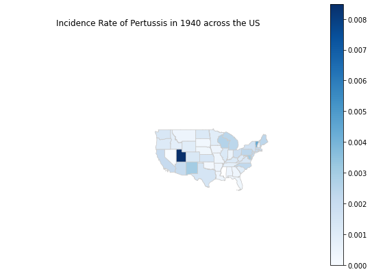

```python
sel = str(input("What year would you like to display (between 1938 and 2011? ")) #take in input
sel = int(sel) #turn into an integer for later

map_pertussis_df = geopandas.GeoDataFrame(map_pertussis_df, geometry='Geometry') #turning the dataframe into a geodataframe object to be used with geopandas to plot

#Here we are trying to find the min and max values to use for our scalebar
#We don't want to do this for each year because looking at the graph over time would be misleading if you kept changing the scalebars
map_pertussis_df.columns.unique()
merged_cols = map_pertussis_df.columns.unique()

merged_cols = merged_cols[1:-1] #only grabbing the years
vmin = map_pertussis_df[merged_cols].min().min()
vmax = map_pertussis_df[merged_cols].max().max()

#Plotting
fig, ax = plt.subplots(1, figsize=(10,7))
map_pertussis_df.plot(column=sel, figsize=(10, 7), cmap='Blues', linewidth=0.8, ax=ax, edgecolor='0.8')
plt.xlim(-2.25e7, -0.5e7) #resetting axes
plt.ylim(0.5, 1.2e7)
ax.axis('off') #remove axis because it means nothing for us

ax.set_title(f'Incidence Rate of Pertussis in {sel} across the US')

sm = plt.cm.ScalarMappable(cmap='Blues', norm=plt.Normalize(vmin=vmin, vmax=vmax)) #for color scalebar
sm._A = []
cbar = fig.colorbar(sm)
```

#### Smallpox

```python
from matplotlib import legend
#for clean data, we will continue to do do seperate operations for each disease type

#create a dictionary of dataframs for every state
states_smallpox = dict()
for k, v in smallpox.groupby('loc'):
  states_smallpox[k] = v

#create an incidence column for every dataframe in the dictionary
for i in states_smallpox:
  states_smallpox[i]['incidence'] =  states_smallpox[i]['number']/states_smallpox[i]['population']
  #set the index to year for easy combining later
  states_smallpox[i].set_index('year', inplace = True)

#create new dataframe of all of the incidences by state for every year
states_smallpox_incidence = pd.DataFrame()

#enter the incidence columns from the state datasets into the incidence dataset
for i in states_smallpox:
  states_smallpox_incidence[i] = states_smallpox[i]['incidence']

states_smallpox_incidence.head()
```

| year | ALABAMA | ARIZONA | ARKANSAS | CALIFORNIA | COLORADO | CONNECTICUT | DELAWARE | DISTRICT OF COLUMBIA | FLORIDA | GEORGIA | ... | SOUTH DAKOTA | TENNESSEE | TEXAS | UTAH | VERMONT | VIRGINIA | WASHINGTON | WEST VIRGINIA | WISCONSIN | WYOMING |
| --- | --- | --- | --- | --- | --- | --- | --- | --- | --- | --- | --- | --- | --- | --- | --- | --- | --- | --- | --- | --- | --- |
| 1928 | 0.000129 | 0.000972 | 0.000134 | 0.000185 | 0.000335 | 0.000102 | 0.000009 | 0.000021 | 0.000110 | 0.000005 | ... | 0.000511 | 0.000258 | 0.000316 | 0.000821 | 0.000028 | 8.213552e-07 | 0.001031 | 0.000767 | 0.000283 | 0.000732 |
| 1929 | 0.000143 | 0.000642 | 0.000107 | 0.000363 | 0.000837 | 0.000027 | 0.000008 | 0.000000 | 0.000025 | 0.000019 | ... | 0.001587 | 0.000094 | 0.000424 | 0.000327 | 0.000387 | 2.597938e-05 | 0.001329 | 0.000351 | 0.000232 | 0.001498 |
| 1930 | 0.000073 | 0.001263 | 0.000221 | 0.000402 | 0.000540 | 0.000000 | 0.000000 | 0.000000 | 0.000019 | 0.000000 | ... | 0.002007 | 0.000162 | 0.000468 | 0.000053 | 0.000219 | 4.120313e-06 | 0.001496 | 0.000451 | 0.000308 | 0.001111 |
| 1931 | 0.000111 | 0.000107 | 0.000407 | 0.000239 | 0.000251 | 0.000061 | 0.000000 | 0.000000 | 0.000019 | 0.000016 | ... | 0.000964 | 0.000133 | 0.000305 | 0.000033 | 0.000663 | 4.907975e-06 | 0.000657 | 0.000144 | 0.000124 | 0.000236 |
| 1932 | 0.000176 | 0.000016 | 0.000196 | 0.000084 | 0.000057 | 0.000053 | 0.000000 | 0.000002 | 0.000022 | 0.000005 | ... | 0.000228 | 0.000162 | 0.000179 | 0.000008 | 0.000486 | 4.078303e-06 | 0.000420 | 0.000035 | 0.000029 | 0.000100 |

5 rows × 49 columns

```python
map_smallpox_df = states_smallpox_incidence.T #transpose to get states in a column
map_smallpox_df.reset_index(inplace=True)
map_smallpox_df.rename(columns={'index':'State'}, inplace=True)
map_smallpox_df = pd.merge(map_smallpox_df, states, on="State", how='left') #we want to use the keys of the incidence values because we know those are 50 states, not including Guam, etc.
map_smallpox_df.head()
```

|  | State | 1928 | 1929 | 1930 | 1931 | 1932 | 1933 | 1934 | 1935 | 1936 | ... | 1941 | 1942 | 1943 | 1944 | 1945 | 1946 | 1947 | 1948 | 1951 | Geometry |
| --- | --- | --- | --- | --- | --- | --- | --- | --- | --- | --- | --- | --- | --- | --- | --- | --- | --- | --- | --- | --- | --- |
| 0 | ALABAMA | 0.000129 | 0.000143 | 0.000073 | 0.000111 | 0.000176 | 0.000031 | 0.000009 | 0.000015 | 0.000004 | ... | 0.000004 | 4.420265e-06 | 6.891799e-06 | 0.000004 | 1.801802e-06 | 0.000002 | 2.039429e-06 | 0.000005 | 3.269042e-07 | POLYGON ((-9841333.855 3579579.495, -9841349.6... |
| 1 | ARIZONA | 0.000972 | 0.000642 | 0.001263 | 0.000107 | 0.000016 | 0.000023 | 0.000007 | 0.000005 | 0.000007 | ... | 0.000033 | 9.541985e-06 | 8.670520e-06 | 0.000011 | 5.050505e-06 | 0.000003 | 0.000000e+00 | 0.000003 | 3.821656e-06 | POLYGON ((-12761162.105 4147165.875, -12761214... |
| 2 | ARKANSAS | 0.000134 | 0.000107 | 0.000221 | 0.000407 | 0.000196 | 0.000124 | 0.000057 | 0.000032 | 0.000007 | ... | 0.000017 | 3.136065e-05 | 3.092784e-05 | 0.000012 | 1.759364e-05 | 0.000006 | 2.178649e-06 | 0.000011 | NaN | POLYGON ((-10515267.713 4101325.818, -10515269... |
| 3 | CALIFORNIA | 0.000185 | 0.000363 | 0.000402 | 0.000239 | 0.000084 | 0.000178 | 0.000030 | 0.000048 | 0.000018 | ... | 0.000002 | 9.049774e-07 | 4.702563e-07 | 0.000002 | 5.351027e-07 | 0.000001 | 1.017087e-07 | 0.000004 | NaN | MULTIPOLYGON (((-13060108.516 3854208.959, -13... |
| 4 | COLORADO | 0.000335 | 0.000837 | 0.000540 | 0.000251 | 0.000057 | 0.000156 | 0.000143 | 0.000160 | 0.000180 | ... | 0.000045 | 1.886792e-05 | 1.040763e-05 | 0.000011 | 5.376344e-06 | 0.000011 | 8.084074e-07 | 0.000013 | NaN | POLYGON ((-12139399.612 4944791.641, -12139399... |

5 rows × 24 columns

```
What year would you like to display (between 1928 and 1968? 1940
```

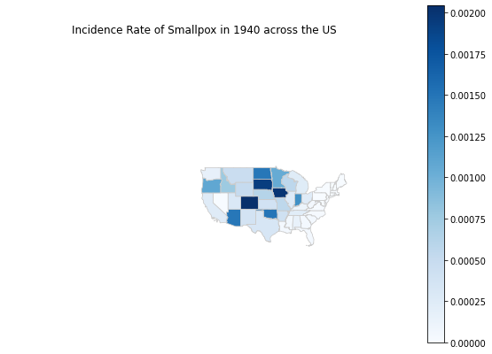

```python
sel = str(input("What year would you like to display (between 1928 and 1968? ")) #take in input
sel = int(sel) #turn into an integer for later

map_smallpox_df = geopandas.GeoDataFrame(map_smallpox_df, geometry='Geometry') #turning the dataframe into a geodataframe object to be used with geopandas to plot

#Here we are trying to find the min and max values to use for our scalebar
#We don't want to do this for each year because looking at the graph over time would be misleading if you kept changing the scalebars
map_smallpox_df.columns.unique()
merged_cols = map_smallpox_df.columns.unique()

merged_cols = merged_cols[1:-1] #only grabbing the years
vmin = map_smallpox_df[merged_cols].min().min()
vmax = map_smallpox_df[merged_cols].max().max()

#Plotting
fig, ax = plt.subplots(1, figsize=(10,7))
map_smallpox_df.plot(column=sel, figsize=(10, 7), cmap='Blues', linewidth=0.8, ax=ax, edgecolor='0.8')
plt.xlim(-2.25e7, -0.5e7) #resetting axes
plt.ylim(0.5, 1.2e7)
ax.axis('off') #remove axis because it means nothing for us

ax.set_title(f'Incidence Rate of Smallpox in {sel} across the US')

sm = plt.cm.ScalarMappable(cmap='Blues', norm=plt.Normalize(vmin=vmin, vmax=vmax)) #for color scalebar
sm._A = []
cbar = fig.colorbar(sm)
```

#### Hepatitis A

```python
from matplotlib import legend
#for clean data, we will continue to do do seperate operations for each disease type

#create a dictionary of dataframs for every state
states_hepa = dict()
for k, v in hepa.groupby('loc'):
  states_hepa[k] = v

#create an incidence column for every dataframe in the dictionary
for i in states_hepa:
  states_hepa[i]['incidence'] = states_hepa[i]['number']/states_hepa[i]['population']
  #set the index to year for easy combining later
  states_hepa[i].set_index('year', inplace = True)

#create new dataframe of all of the incidences by state for every year
states_hepa_incidence = pd.DataFrame()

#enter the incidence columns from the state datasets into the incidence dataset
for i in states_hepa:
  states_hepa_incidence[i] = states_hepa[i]['incidence']

states_hepa_incidence.head()
```

| year | ALABAMA | ALASKA | ARIZONA | ARKANSAS | CALIFORNIA | COLORADO | CONNECTICUT | DELAWARE | DISTRICT OF COLUMBIA | FLORIDA | ... | SOUTH DAKOTA | TENNESSEE | TEXAS | UTAH | VERMONT | VIRGINIA | WASHINGTON | WEST VIRGINIA | WISCONSIN | WYOMING |
| --- | --- | --- | --- | --- | --- | --- | --- | --- | --- | --- | --- | --- | --- | --- | --- | --- | --- | --- | --- | --- | --- |
| 1966 | 0.000093 | 0.000332 | 0.000257 | 0.000157 | 0.000315 | 0.000145 | 0.000115 | 0.000153 | 0.000048 | 0.000106 | ... | 0.000020 | 0.000261 | 0.000172 | 0.000168 | 0.000056 | 0.000130 | 0.000189 | 0.000137 | 0.000088 | 0.000167 |
| 1967 | 0.000084 | 0.000140 | 0.000237 | 0.000155 | 0.000390 | 0.000143 | 0.000199 | 0.000330 | 0.000053 | 0.000103 | ... | 0.000019 | 0.000217 | 0.000257 | 0.000155 | 0.000035 | 0.000157 | 0.000277 | 0.000205 | 0.000104 | 0.000202 |
| 1968 | 0.000091 | 0.000295 | 0.000253 | 0.000087 | 0.000558 | 0.000337 | 0.000169 | 0.000273 | 0.000086 | 0.000173 | ... | 0.000115 | 0.000267 | 0.000202 | 0.000252 | 0.000156 | 0.000127 | 0.000364 | 0.000189 | 0.000125 | 0.000114 |
| 1969 | 0.000110 | 0.000213 | 0.000304 | 0.000099 | 0.000459 | 0.000271 | 0.000206 | 0.000124 | 0.000076 | 0.000204 | ... | 0.000129 | 0.000260 | 0.000209 | 0.000271 | 0.000341 | 0.000093 | 0.000377 | 0.000194 | 0.000095 | 0.000246 |
| 1970 | 0.000118 | 0.000358 | 0.000324 | 0.000107 | 0.000463 | 0.000397 | 0.000281 | 0.000239 | 0.000116 | 0.000252 | ... | 0.000031 | 0.000316 | 0.000238 | 0.000282 | 0.000808 | 0.000285 | 0.000399 | 0.000216 | 0.000108 | 0.000244 |

5 rows × 51 columns

```python
map_hepa_df = states_hepa_incidence.T #transpose to get states in a column
map_hepa_df.reset_index(inplace=True)
map_hepa_df.rename(columns={'index':'State'}, inplace=True)
map_hepa_df = pd.merge(map_hepa_df, states, on="State", how='left') #we want to use the keys of the incidence values because we know those are 50 states, not including Guam, etc.
map_hepa_df.head()
```

|  | State | 1966 | 1967 | 1968 | 1969 | 1970 | 1971 | 1972 | 1973 | 1974 | ... | 2003 | 2004 | 2005 | 2006 | 2007 | 2008 | 2009 | 2010 | 2011 | Geometry |
| --- | --- | --- | --- | --- | --- | --- | --- | --- | --- | --- | --- | --- | --- | --- | --- | --- | --- | --- | --- | --- | --- |
| 0 | ALABAMA | 0.000093 | 0.000084 | 0.000091 | 0.000110 | 0.000118 | 0.000107 | 0.000096 | 0.000129 | 0.000066 | ... | 0.000003 | 0.000001 | 0.000007 | 0.000004 | 0.000004 | 0.000002 | 0.000002 | 0.000002 | 0.000001 | POLYGON ((-9841333.855 3579579.495, -9841349.6... |
| 1 | ALASKA | 0.000332 | 0.000140 | 0.000295 | 0.000213 | 0.000358 | 0.000296 | 0.000602 | 0.000660 | 0.000659 | ... | 0.000012 | 0.000006 | 0.000004 | NaN | 0.000004 | 0.000004 | 0.000009 | 0.000006 | 0.000001 | MULTIPOLYGON (((-15108567.654 8339788.089, -15... |
| 2 | ARIZONA | 0.000257 | 0.000237 | 0.000253 | 0.000304 | 0.000324 | 0.000446 | 0.000311 | 0.000072 | 0.000224 | ... | 0.000042 | 0.000036 | 0.000040 | 0.000011 | 0.000026 | 0.000016 | 0.000011 | 0.000011 | 0.000003 | POLYGON ((-12761162.105 4147165.875, -12761214... |
| 3 | ARKANSAS | 0.000157 | 0.000155 | 0.000087 | 0.000099 | 0.000107 | 0.000117 | 0.000135 | 0.000067 | 0.000206 | ... | 0.000006 | 0.000019 | 0.000006 | 0.000008 | 0.000004 | 0.000001 | 0.000002 | 0.000000 | 0.000000 | POLYGON ((-10515267.713 4101325.818, -10515269... |
| 4 | CALIFORNIA | 0.000315 | 0.000390 | 0.000558 | 0.000459 | 0.000463 | 0.000467 | 0.000345 | 0.000325 | 0.000258 | ... | 0.000030 | 0.000022 | 0.000025 | 0.000019 | 0.000009 | 0.000009 | 0.000006 | 0.000005 | 0.000005 | MULTIPOLYGON (((-13060108.516 3854208.959, -13... |

5 rows × 48 columns

```
What year would you like to display (between 1966 and 2011? 1970
```

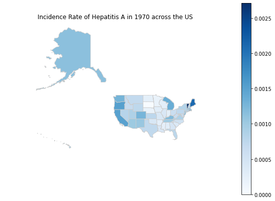

```python
sel = str(input("What year would you like to display (between 1966 and 2011? ")) #take in input
sel = int(sel) #turn into an integer for later

map_hepa_df = geopandas.GeoDataFrame(map_hepa_df, geometry='Geometry') #turning the dataframe into a geodataframe object to be used with geopandas to plot

#Here we are trying to find the min and max values to use for our scalebar
#We don't want to do this for each year because looking at the graph over time would be misleading if you kept changing the scalebars
map_hepa_df.columns.unique()
merged_cols = map_hepa_df.columns.unique()

merged_cols = merged_cols[1:-1] #only grabbing the years
vmin = map_hepa_df[merged_cols].min().min()
vmax = map_hepa_df[merged_cols].max().max()

#Plotting
fig, ax = plt.subplots(1, figsize=(10,7))
map_hepa_df.plot(column=sel, figsize=(10, 7), cmap='Blues', linewidth=0.8, ax=ax, edgecolor='0.8')
plt.xlim(-2.25e7, -0.5e7) #resetting axes
plt.ylim(0.5, 1.2e7)
ax.axis('off') #remove axis because it means nothing for us

ax.set_title(f'Incidence Rate of Hepatitis A in {sel} across the US')

sm = plt.cm.ScalarMappable(cmap='Blues', norm=plt.Normalize(vmin=vmin, vmax=vmax)) #for color scalebar
sm._A = []
cbar = fig.colorbar(sm)
```

#### Rubella

```python
from matplotlib import legend
#for clean data, we will continue to do do seperate operations for each disease type

#create a dictionary of dataframs for every state
states_rubella = dict()
for k, v in rubella.groupby('loc'):
  states_rubella[k] = v

#create an incidence column for every dataframe in the dictionary
for i in states_rubella:
  states_rubella[i]['incidence'] = states_rubella[i]['number']/states_rubella[i]['population']
  #set the index to year for easy combining later
  states_rubella[i].set_index('year', inplace = True)

#create new dataframe of all of the incidences by state for every year
states_rubella_incidence = pd.DataFrame()

#enter the incidence columns from the state datasets into the incidence dataset
for i in states_rubella:
  states_rubella_incidence[i] = states_rubella[i]['incidence']

states_rubella_incidence.head()
```

| year | ALABAMA | ALASKA | ARIZONA | ARKANSAS | CALIFORNIA | COLORADO | CONNECTICUT | DELAWARE | DISTRICT OF COLUMBIA | FLORIDA | ... | SOUTH DAKOTA | TENNESSEE | TEXAS | UTAH | VERMONT | VIRGINIA | WASHINGTON | WEST VIRGINIA | WISCONSIN | WYOMING |
| --- | --- | --- | --- | --- | --- | --- | --- | --- | --- | --- | --- | --- | --- | --- | --- | --- | --- | --- | --- | --- | --- |
| 1966 | 0.000032 | 0.000413 | 0.001595 | 0.000005 | 0.000149 | 0.000370 | 0.000756 | 0.000103 | 0.000019 | 0.000231 | ... | 0.000003 | 0.000676 | 0.000013 | 0.000080 | 0.000385 | 0.000216 | 0.001024 | 0.000573 | 0.001194 | 0.000740 |
| 1967 | 0.000062 | 0.001137 | 0.000593 | 0.000009 | 0.000473 | 0.000882 | 0.000622 | 0.000141 | 0.000009 | 0.000184 | ... | 0.000004 | 0.000333 | 0.000059 | 0.000080 | 0.000506 | 0.000144 | 0.000955 | 0.000334 | 0.000713 | 0.000012 |
| 1968 | 0.000117 | 0.001014 | 0.000416 | 0.000002 | 0.000252 | 0.000418 | 0.001025 | 0.000281 | 0.000018 | 0.000229 | ... | NaN | 0.000293 | 0.000265 | 0.000107 | 0.000212 | 0.000140 | 0.000561 | 0.000499 | 0.000686 | 0.000037 |
| 1969 | 0.000040 | 0.001574 | 0.000471 | 0.000104 | 0.000306 | 0.000635 | 0.000548 | 0.000365 | 0.000209 | 0.000299 | ... | NaN | 0.000428 | 0.000378 | 0.000146 | 0.000275 | 0.000334 | 0.000540 | 0.001348 | 0.000720 | 0.000246 |
| 1970 | 0.000109 | 0.000269 | 0.000328 | 0.000019 | 0.000258 | 0.000188 | 0.000203 | 0.000081 | 0.000028 | 0.000466 | ... | 0.000006 | 0.000381 | 0.000723 | 0.000157 | 0.000150 | 0.000162 | 0.001415 | 0.000800 | 0.000514 | 0.000400 |

5 rows × 51 columns

```python
map_rubella_df = states_rubella_incidence.T #transpose to get states in a column
map_rubella_df.reset_index(inplace=True)
map_rubella_df.rename(columns={'index':'State'}, inplace=True)
map_rubella_df = pd.merge(map_rubella_df, states, on="State", how='left') #we want to use the keys of the incidence values because we know those are 50 states, not including Guam, etc.
map_rubella_df.head()
```

|  | State | 1966 | 1967 | 1968 | 1969 | 1970 | 1971 | 1972 | 1973 | 1974 | ... | 1981 | 1983 | 1984 | 1989 | 1990 | 1996 | 1998 | 1999 | 2000 | Geometry |
| --- | --- | --- | --- | --- | --- | --- | --- | --- | --- | --- | --- | --- | --- | --- | --- | --- | --- | --- | --- | --- | --- |
| 0 | ALABAMA | 0.000032 | 0.000062 | 0.000117 | 0.000040 | 0.000109 | 0.000064 | 0.000019 | 0.000061 | 1.766874e-05 | ... | 2.547598e-07 | 2.530480e-07 | 7.551876e-07 | 2.474888e-07 | 2.469102e-07 | 4.617762e-07 | 0.000000e+00 | 2.257264e-07 | 6.738773e-07 | POLYGON ((-9841333.855 3579579.495, -9841349.6... |
| 1 | ALASKA | 0.000413 | 0.001137 | 0.001014 | 0.001574 | 0.000269 | 0.000126 | 0.000085 | 0.000085 | NaN | ... | 2.224170e-06 | 1.946654e-06 | 1.877952e-06 | NaN | NaN | NaN | NaN | NaN | NaN | MULTIPOLYGON (((-15108567.654 8339788.089, -15... |
| 2 | ARIZONA | 0.001595 | 0.000593 | 0.000416 | 0.000471 | 0.000328 | 0.000200 | 0.000173 | 0.000012 | 8.753321e-07 | ... | 7.612823e-06 | 2.608297e-06 | 1.256464e-06 | NaN | 8.414545e-06 | 2.180103e-07 | 4.095556e-07 | 2.189568e-06 | 1.935473e-07 | POLYGON ((-12761162.105 4147165.875, -12761214... |
| 3 | ARKANSAS | 0.000005 | 0.000009 | 0.000002 | 0.000104 | 0.000019 | 0.000167 | 0.000035 | 0.000049 | 3.704517e-06 | ... | 3.051097e-06 | NaN | 1.289188e-06 | 4.254007e-07 | 1.273028e-06 | NaN | NaN | 7.541876e-07 | NaN | POLYGON ((-10515267.713 4101325.818, -10515269... |
| 4 | CALIFORNIA | 0.000149 | 0.000473 | 0.000252 | 0.000306 | 0.000258 | 0.000407 | 0.000230 | 0.000119 | 6.639475e-05 | ... | 1.913779e-05 | 1.029237e-05 | 6.089003e-06 | 3.797040e-06 | 1.552095e-05 | 1.499118e-06 | 6.062870e-08 | 1.492573e-07 | 3.235811e-07 | MULTIPOLYGON (((-13060108.516 3854208.959, -13... |

5 rows × 26 columns

```
What year would you like to display (between 1966 and 2002? 1970
```

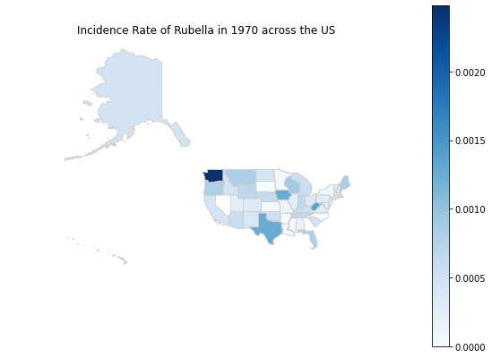

```python
sel = str(input("What year would you like to display (between 1966 and 2002? ")) #take in input
sel = int(sel) #turn into an integer for later

map_rubella_df = geopandas.GeoDataFrame(map_rubella_df, geometry='Geometry') #turning the dataframe into a geodataframe object to be used with geopandas to plot

#Here we are trying to find the min and max values to use for our scalebar
#We don't want to do this for each year because looking at the graph over time would be misleading if you kept changing the scalebars
map_rubella_df.columns.unique()
merged_cols = map_rubella_df.columns.unique()

merged_cols = merged_cols[1:-1] #only grabbing the years
vmin = map_rubella_df[merged_cols].min().min()
vmax = map_rubella_df[merged_cols].max().max()

#Plotting
fig, ax = plt.subplots(1, figsize=(10,7))
map_rubella_df.plot(column=sel, figsize=(10, 7), cmap='Blues', linewidth=0.8, ax=ax, edgecolor='0.8')
plt.xlim(-2.25e7, -0.5e7) #resetting axes
plt.ylim(0.5, 1.2e7)
ax.axis('off') #remove axis because it means nothing for us

ax.set_title(f'Incidence Rate of Rubella in {sel} across the US')

sm = plt.cm.ScalarMappable(cmap='Blues', norm=plt.Normalize(vmin=vmin, vmax=vmax)) #for color scalebar
sm._A = []
cbar = fig.colorbar(sm)
```

#### Mumps

```python
from matplotlib import legend
#for clean data, we will continue to do do seperate operations for each disease type

#create a dictionary of dataframs for every state
states_mumps = dict()
for k, v in mumps.groupby('loc'):
  states_mumps[k] = v

#create an incidence column for every dataframe in the dictionary
for i in states_mumps:
  states_mumps[i]['incidence'] = states_mumps[i]['number']/states_mumps[i]['population']
  #set the index to year for easy combining later
  states_mumps[i].set_index('year', inplace = True)

#create new dataframe of all of the incidences by state for every year
states_mumps_incidence = pd.DataFrame()

#enter the incidence columns from the state datasets into the incidence dataset
for i in states_mumps:
  states_mumps_incidence[i] = states_mumps[i]['incidence']

states_mumps_incidence
```

| year | ALABAMA | ALASKA | ARIZONA | ARKANSAS | CALIFORNIA | COLORADO | CONNECTICUT | DELAWARE | DISTRICT OF COLUMBIA | FLORIDA | ... | SOUTH DAKOTA | TENNESSEE | TEXAS | UTAH | VERMONT | VIRGINIA | WASHINGTON | WEST VIRGINIA | WISCONSIN | WYOMING |
| --- | --- | --- | --- | --- | --- | --- | --- | --- | --- | --- | --- | --- | --- | --- | --- | --- | --- | --- | --- | --- | --- |
| 1968 | 1.590250e-04 | 0.002519 | 1.197384e-03 | 9.989485e-06 | 0.000871 | 1.325472e-03 | 1.293860e-03 | 0.000566 | 0.000303 | 3.472719e-04 | ... | NaN | 1.531717e-03 | 1.038543e-03 | 6.754130e-04 | 0.002898 | 2.775340e-04 | 2.005810e-03 | 0.001976 | 0.003547 | 0.001231 |
| 1969 | 6.802326e-05 | 0.003108 | 1.209557e-03 | 4.652378e-05 | 0.000407 | 3.965836e-04 | 1.328333e-03 | 0.000241 | 0.000121 | 2.478542e-04 | ... | NaN | 5.848088e-04 | 7.306474e-04 | 3.190067e-04 | 0.002872 | 2.798006e-04 | 1.301825e-03 | 0.001574 | 0.001948 | 0.000024 |
| 1970 | 1.120936e-04 | 0.000919 | 5.206207e-04 | 7.909499e-05 | 0.000306 | 6.663703e-04 | 1.192118e-03 | 0.000648 | 0.000291 | 4.061018e-04 | ... | 0.000086 | 8.229503e-04 | 5.188600e-04 | 1.171458e-04 | 0.001620 | 4.689699e-04 | 1.690764e-03 | 0.001432 | 0.002543 | 0.000129 |
| 1971 | 2.895971e-04 | 0.000287 | 6.199301e-04 | 7.827060e-05 | 0.000365 | 6.562370e-04 | 5.155279e-04 | 0.000321 | 0.000132 | 3.836802e-04 | ... | 0.000444 | 1.245051e-03 | 7.496291e-04 | 1.717382e-04 | 0.000764 | 2.219932e-04 | 1.847219e-03 | 0.001431 | 0.003726 | 0.001226 |
| 1972 | 2.371654e-04 | 0.000771 | 4.594156e-04 | 1.053779e-04 | 0.000341 | 3.309470e-04 | 3.647548e-04 | 0.000306 | 0.000042 | 1.804467e-04 | ... | 0.000177 | 5.121280e-04 | 4.096662e-04 | 1.205087e-04 | 0.000292 | 2.680926e-04 | 1.138617e-03 | 0.001411 | 0.001797 | 0.000983 |
| 1973 | 2.081898e-04 | 0.002557 | 7.376768e-05 | 1.603690e-04 | 0.000268 | 2.376637e-04 | 5.149563e-04 | 0.000490 | 0.000221 | 3.134202e-04 | ... | 0.000029 | 6.657159e-04 | 2.992999e-04 | 1.307820e-04 | 0.000562 | 1.571091e-04 | 4.402884e-04 | 0.001465 | 0.001040 | 0.001193 |
| 1974 | 1.666298e-04 | 0.000396 | NaN | 8.520388e-05 | 0.000116 | 2.296813e-04 | 5.437145e-04 | 0.000317 | 0.000071 | 2.165894e-04 | ... | 0.000004 | 6.590940e-04 | 2.506197e-04 | 6.229622e-05 | 0.000069 | 1.501765e-04 | 5.851427e-04 | 0.001807 | 0.000730 | 0.000026 |
| 1975 | 1.212806e-04 | 0.000130 | NaN | 8.524713e-05 | 0.000170 | 2.564292e-04 | 2.633512e-04 | 0.000024 | 0.000222 | 1.089141e-04 | ... | 0.000009 | 5.544145e-04 | 3.014548e-04 | 1.482437e-04 | 0.000025 | 1.661505e-04 | 1.233482e-03 | 0.000783 | 0.001317 | 0.000005 |
| 1976 | 1.028991e-04 | 0.000094 | NaN | 3.666801e-05 | 0.000079 | 1.045940e-04 | 2.414346e-04 | 0.000150 | 0.000159 | 4.076248e-05 | ... | 0.000016 | 3.857179e-04 | 1.315086e-04 | 1.674862e-04 | 0.000102 | 4.332662e-05 | 2.335774e-04 | 0.000449 | 0.000908 | 0.000002 |
| 1977 | 7.515979e-05 | 0.000084 | NaN | 6.731674e-05 | 0.000036 | 1.109606e-04 | 1.177374e-04 | 0.000242 | 0.000009 | 2.889465e-05 | ... | 0.000086 | 1.422103e-04 | 7.251621e-05 | 6.069425e-05 | 0.000016 | 2.428732e-05 | 8.562452e-05 | 0.000111 | 0.000404 | 0.000009 |
| 1978 | 1.130295e-04 | 0.000037 | 1.024446e-05 | 2.769299e-04 | 0.000023 | 6.142002e-05 | 4.489784e-05 | 0.000094 | 0.000003 | 3.278111e-05 | ... | 0.000016 | 1.021824e-04 | 1.099481e-04 | 1.175859e-04 | 0.000012 | 3.654898e-05 | 5.326521e-05 | 0.000072 | 0.000284 | 0.000004 |
| 1979 | 7.190756e-06 | 0.000037 | 2.391275e-05 | 2.803491e-04 | 0.000019 | 4.083096e-05 | 6.564602e-05 | 0.000160 | 0.000002 | 1.559562e-05 | ... | 0.000016 | 2.374148e-05 | 6.367193e-05 | 7.939566e-05 | 0.000020 | 1.907677e-05 | 5.977509e-05 | 0.000066 | 0.000267 | NaN |
| 1980 | 8.676721e-06 | 0.000038 | 1.530191e-05 | 1.090179e-05 | 0.000017 | 2.182748e-05 | 3.196077e-05 | 0.000067 | 0.000008 | 1.785579e-05 | ... | 0.000006 | 7.347129e-06 | 1.410522e-05 | 1.913596e-05 | 0.000023 | 1.579693e-05 | 3.116345e-05 | 0.000072 | 0.000077 | NaN |
| 1981 | 4.840436e-06 | 0.000042 | 1.314942e-05 | 3.051097e-06 | 0.000016 | 1.469837e-05 | 1.624715e-05 | 0.000015 | 0.000013 | 1.231926e-05 | ... | 0.000001 | 5.165688e-06 | 1.408872e-05 | 1.347610e-05 | 0.000019 | 2.384948e-05 | 3.834865e-05 | 0.000059 | 0.000041 | 0.000006 |
| 1982 | 2.541876e-06 | 0.000037 | 2.121980e-05 | 3.469570e-06 | 0.000016 | 6.701493e-06 | 8.221723e-06 | 0.000021 | NaN | 3.907031e-06 | ... | 0.000001 | 5.794304e-06 | 1.631572e-05 | 1.316661e-05 | 0.000013 | 7.907046e-06 | 2.371946e-05 | 0.000060 | 0.000026 | 0.000004 |
| 1983 | 5.060959e-07 | 0.000031 | 2.934334e-05 | 8.621552e-07 | 0.000012 | 1.545745e-05 | 6.918209e-06 | 0.000010 | NaN | NaN | ... | NaN | 6.187674e-06 | 1.355650e-05 | 9.245893e-06 | 0.000028 | 5.847052e-06 | 1.105060e-05 | 0.000029 | 0.000019 | 0.000008 |
| 1984 | 1.258646e-06 | 0.000032 | 6.376553e-05 | 3.437835e-06 | 0.000014 | 9.661164e-06 | 3.123896e-06 | 0.000005 | 0.000002 | 3.347688e-06 | ... | NaN | 3.605288e-06 | 1.112290e-05 | 6.695437e-06 | 0.000009 | 3.674442e-06 | 1.431786e-05 | 0.000022 | 0.000022 | 0.000004 |
| 1985 | 2.505281e-07 | 0.000018 | 3.748192e-05 | 3.001736e-06 | 0.000014 | 8.031012e-06 | 2.481590e-06 | 0.000000 | NaN | 4.799655e-06 | ... | NaN | 3.798504e-06 | 1.902046e-05 | 3.006915e-06 | 0.000006 | 8.431268e-06 | 9.207855e-06 | 0.000039 | 0.000020 | 0.000004 |
| 1986 | 9.961985e-07 | 0.000019 | 5.847948e-05 | 7.855342e-05 | 0.000010 | 5.520660e-06 | 6.774878e-06 | 0.000000 | 0.000002 | 4.584371e-06 | ... | 0.000001 | 4.934217e-05 | 1.299499e-05 | 9.534485e-06 | 0.000006 | 7.585632e-06 | 5.075133e-06 | 0.000026 | 0.000040 | NaN |
| 1987 | 1.590519e-05 | 0.000015 | 5.346258e-05 | 1.233642e-04 | 0.000012 | 1.072869e-05 | 4.890046e-06 | NaN | 0.000002 | 4.875514e-06 | ... | 0.000129 | 2.442748e-04 | 1.901959e-05 | 7.103231e-06 | 0.000013 | 1.474264e-05 | 1.573312e-05 | 0.000021 | 0.000104 | NaN |
| 1988 | 4.466255e-06 | 0.000026 | 3.892678e-05 | 5.796217e-05 | 0.000015 | 1.068435e-05 | 0.000000e+00 | 0.000002 | 0.000471 | 3.006873e-06 | ... | 0.000001 | 4.531930e-05 | 1.749299e-05 | 4.103492e-06 | 0.000011 | 2.712309e-05 | 1.369483e-05 | 0.000011 | 0.000024 | 0.000015 |
| 1989 | 7.424664e-06 | 0.000002 | 3.546846e-05 | 8.678174e-05 | 0.000012 | 1.973049e-05 | 3.954835e-06 | 0.000003 | 0.000196 | 3.478146e-06 | ... | NaN | 2.152881e-05 | 3.508667e-05 | 1.102824e-05 | 0.000007 | 2.295002e-05 | 1.150679e-05 | 0.000010 | 0.000010 | 0.000009 |
| 1990 | 4.691294e-06 | 0.000007 | 3.338674e-05 | 5.855929e-05 | 0.000016 | 8.465306e-06 | 3.645237e-06 | 0.000007 | 0.000058 | 1.319696e-05 | ... | NaN | 1.103281e-05 | 2.673428e-05 | 8.086769e-06 | 0.000004 | 1.528097e-05 | 1.244125e-05 | 0.000024 | 0.000010 | 0.000007 |
| 1991 | 3.415337e-06 | 0.000026 | 3.616134e-05 | 1.846301e-05 | 0.000013 | 4.133306e-05 | 3.633176e-06 | 0.000010 | 0.000040 | 2.685156e-05 | ... | 0.000003 | 3.624219e-05 | 1.954247e-05 | 8.428008e-06 | 0.000007 | 1.095027e-05 | 3.462257e-05 | 0.000014 | 0.000005 | 0.000011 |
| 1992 | 2.888772e-06 | 0.000005 | 1.532277e-05 | 3.311280e-06 | 0.000007 | 8.867432e-06 | 2.120755e-06 | 0.000010 | 0.000012 | 1.926662e-05 | ... | NaN | 3.564539e-06 | 1.683583e-05 | 1.578834e-05 | 0.000002 | 9.042286e-06 | 3.487860e-06 | 0.000015 | 0.000003 | 0.000000 |
| 1993 | 5.220443e-06 | 0.000018 | 5.165493e-06 | 1.628464e-06 | 0.000005 | 3.597387e-06 | 1.510951e-06 | 0.000010 | 0.000002 | 3.374695e-06 | ... | NaN | 3.114304e-06 | 1.244383e-05 | 4.214066e-06 | 0.000000 | 5.069413e-06 | 2.652097e-06 | 0.000012 | 0.000004 | 0.000011 |
| 1994 | 2.816750e-06 | 0.000007 | 2.261437e-05 | 2.004796e-06 | 0.000005 | 8.055491e-07 | 3.618686e-06 | NaN | NaN | 2.387734e-06 | ... | NaN | 1.720368e-06 | 2.036192e-05 | 1.326229e-05 | NaN | 6.976950e-06 | 1.674368e-06 | 0.000003 | 0.000002 | 0.000006 |
| 1995 | 4.654627e-07 | 0.000020 | 1.353638e-06 | 3.944152e-06 | 0.000006 | 5.226500e-07 | 6.016587e-07 | NaN | NaN | 1.100574e-06 | ... | NaN | 5.631755e-07 | 1.424144e-06 | 4.964807e-06 | NaN | 3.597827e-06 | 2.554266e-06 | NaN | NaN | NaN |
| 1996 | 1.616217e-06 | 0.000005 | 2.180103e-07 | 3.887860e-07 | 0.000003 | 7.653116e-07 | NaN | NaN | 0.000000 | 1.885095e-06 | ... | NaN | 9.230810e-07 | 1.240929e-06 | 9.671292e-07 | NaN | 2.370060e-06 | 3.770365e-06 | NaN | 0.000000 | 0.000002 |
| 1997 | 1.831529e-06 | 0.000007 | 6.966449e-06 | 0.000000e+00 | 0.000004 | 7.465857e-07 | 0.000000e+00 | NaN | NaN | 2.304708e-06 | ... | NaN | 1.272905e-06 | 2.380914e-06 | 4.245716e-06 | NaN | 2.782178e-06 | 2.995728e-06 | 0.000001 | 0.000000 | 0.000002 |
| 1998 | 9.081207e-07 | 0.000003 | 1.228667e-06 | 3.426889e-06 | 0.000002 | 2.186250e-06 | 8.914372e-07 | NaN | NaN | 2.130880e-06 | ... | NaN | 3.590635e-07 | 1.537887e-06 | 2.770134e-06 | NaN | 1.449083e-06 | 1.906557e-06 | NaN | NaN | 0.000002 |
| 1999 | 2.482991e-06 | 0.000005 | 1.592413e-06 | NaN | 0.000002 | 1.183147e-06 | NaN | NaN | 0.000004 | 1.713261e-06 | ... | NaN | NaN | 1.118774e-06 | 2.722963e-06 | 0.000000 | 1.428536e-06 | 3.423155e-07 | NaN | 0.000000 | NaN |
| 2000 | 8.985031e-07 | 0.000013 | 1.161284e-06 | 1.866864e-06 | 0.000002 | 6.931496e-07 | 8.793203e-07 | NaN | NaN | 6.854813e-07 | ... | NaN | 3.506777e-07 | 1.002580e-06 | 2.673423e-06 | NaN | 1.548307e-06 | 1.860899e-06 | NaN | NaN | 0.000008 |
| 2002 | 4.471852e-07 | NaN | 0.000000e+00 | NaN | 0.000002 | 4.440236e-07 | 0.000000e+00 | NaN | NaN | 3.597056e-07 | ... | NaN | 1.723156e-07 | 6.448407e-07 | 2.998535e-06 | NaN | 4.118876e-07 | NaN | NaN | 0.000000 | NaN |

34 rows × 51 columns

```python
map_mumps_df = states_mumps_incidence.T #transpose to get states in a column
map_mumps_df.reset_index(inplace=True)
map_mumps_df.rename(columns={'index':'State'}, inplace=True)
map_mumps_df = pd.merge(map_mumps_df, states, on="State", how='left') #we want to use the keys of the incidence values because we know those are 50 states, not including Guam, etc.
map_mumps_df.head()
```

|  | State | 1968 | 1969 | 1970 | 1971 | 1972 | 1973 | 1974 | 1975 | 1976 | ... | 1993 | 1994 | 1995 | 1996 | 1997 | 1998 | 1999 | 2000 | 2002 | Geometry |
| --- | --- | --- | --- | --- | --- | --- | --- | --- | --- | --- | --- | --- | --- | --- | --- | --- | --- | --- | --- | --- | --- |
| 0 | ALABAMA | 0.000159 | 0.000068 | 0.000112 | 0.000290 | 0.000237 | 0.000208 | 0.000167 | 0.000121 | 0.000103 | ... | 0.000005 | 0.000003 | 4.654627e-07 | 1.616217e-06 | 0.000002 | 9.081207e-07 | 0.000002 | 8.985031e-07 | 4.471852e-07 | POLYGON ((-9841333.855 3579579.495, -9841349.6... |
| 1 | ALASKA | 0.002519 | 0.003108 | 0.000919 | 0.000287 | 0.000771 | 0.002557 | 0.000396 | 0.000130 | 0.000094 | ... | 0.000018 | 0.000007 | 1.985401e-05 | 4.929597e-06 | 0.000007 | 3.226160e-06 | 0.000005 | 1.274902e-05 | NaN | MULTIPOLYGON (((-15108567.654 8339788.089, -15... |
| 2 | ARIZONA | 0.001197 | 0.001210 | 0.000521 | 0.000620 | 0.000459 | 0.000074 | NaN | NaN | NaN | ... | 0.000005 | 0.000023 | 1.353638e-06 | 2.180103e-07 | 0.000007 | 1.228667e-06 | 0.000002 | 1.161284e-06 | 0.000000e+00 | POLYGON ((-12761162.105 4147165.875, -12761214... |
| 3 | ARKANSAS | 0.000010 | 0.000047 | 0.000079 | 0.000078 | 0.000105 | 0.000160 | 0.000085 | 0.000085 | 0.000037 | ... | 0.000002 | 0.000002 | 3.944152e-06 | 3.887860e-07 | 0.000000 | 3.426889e-06 | NaN | 1.866864e-06 | NaN | POLYGON ((-10515267.713 4101325.818, -10515269... |
| 4 | CALIFORNIA | 0.000871 | 0.000407 | 0.000306 | 0.000365 | 0.000341 | 0.000268 | 0.000116 | 0.000170 | 0.000079 | ... | 0.000005 | 0.000005 | 6.467574e-06 | 3.185625e-06 | 0.000004 | 1.940119e-06 | 0.000002 | 1.853237e-06 | 1.892408e-06 | MULTIPOLYGON (((-13060108.516 3854208.959, -13... |

5 rows × 36 columns

```
What year would you like to display (between 1968 and 2002? 1970
```

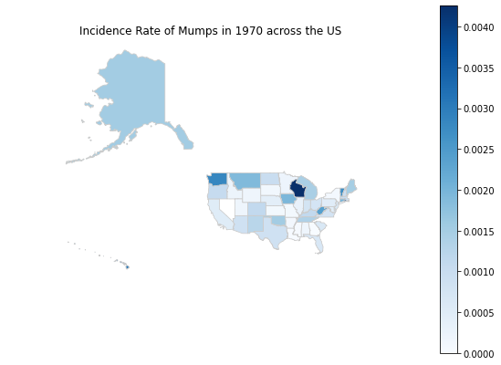

```python
sel = str(input("What year would you like to display (between 1968 and 2002? ")) #take in input
sel = int(sel) #turn into an integer for later

map_mumps_df = geopandas.GeoDataFrame(map_mumps_df, geometry='Geometry') #turning the dataframe into a geodataframe object to be used with geopandas to plot

#Here we are trying to find the min and max values to use for our scalebar
#We don't want to do this for each year because looking at the graph over time would be misleading if you kept changing the scalebars
map_mumps_df.columns.unique()
merged_cols = map_mumps_df.columns.unique()

merged_cols = merged_cols[1:-1] #only grabbing the years
vmin = map_mumps_df[merged_cols].min().min()
vmax = map_mumps_df[merged_cols].max().max()

#Plotting
fig, ax = plt.subplots(1, figsize=(10,7))
map_mumps_df.plot(column=sel, figsize=(10, 7), cmap='Blues', linewidth=0.8, ax=ax, edgecolor='0.8')
plt.xlim(-2.25e7, -0.5e7) #resetting axes
plt.ylim(0.5, 1.2e7)
ax.axis('off') #remove axis because it means nothing for us

ax.set_title(f'Incidence Rate of Mumps in {sel} across the US')

sm = plt.cm.ScalarMappable(cmap='Blues', norm=plt.Normalize(vmin=vmin, vmax=vmax)) #for color scalebar
sm._A = []
cbar = fig.colorbar(sm)
```

### Incidence Analysis

Now that we have an understanding and datasets portraying incidence on a national and state wide scale, we can see how the states compare to the national average and establish a ranking of what states were affected by a given disease the most each year

We will start by creating a dataset that has the incidence for every state every year as well as the entire country

### Measles

```python
#reset index to year for joining
measles_incidence.set_index('year', inplace = True)
```

```python
#grab the national incidence and add it into a new dataframe with state incidences
US = measles_incidence['incidence']
US_state_measles_incidence = states_measles_incidence.join(US)
```

```python
#rename column
US_state_measles_incidence.rename(columns={'incidence':'UNITED STATES'}, inplace = True)
```

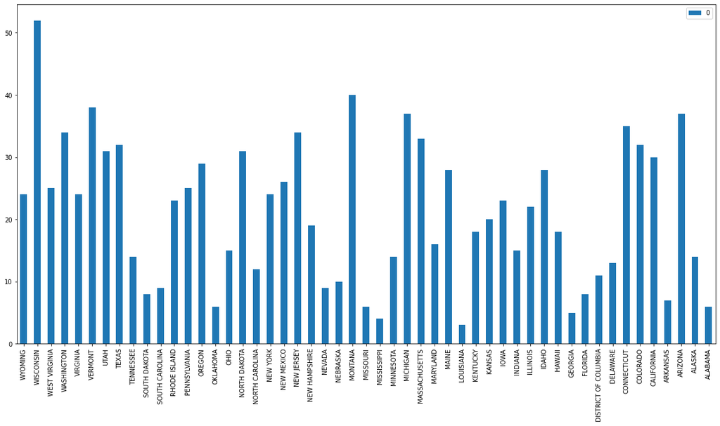

```python
from pandas.core.groupby.groupby import DataFrame
states = list(US_state_measles_incidence.columns)
states.remove('UNITED STATES')

measles_compare_incidence = US_state_measles_incidence[states].div(US_state_measles_incidence['UNITED STATES'], axis=0)

measles_hist = DataFrame()

for state in measles_compare_incidence:
  count = measles_compare_incidence[state][measles_compare_incidence[state] > 1].count()
  measles_hist.insert(0, state, [count])

measles_hist = measles_hist.T

measles_hist.plot.bar(figsize=(20, 10))
```

```python
###
```

### Polio

```python
#reset index to year for joining
polio_incidence.set_index('year', inplace = True)
```

```python
#grab the national incidence and add it into a new dataframe with state incidences
US = polio_incidence['incidence']
US_state_polio_incidence = states_polio_incidence.join(US)
```

```python
#rename column
US_state_polio_incidence.rename(columns={'incidence':'UNITED STATES'}, inplace = True)
```

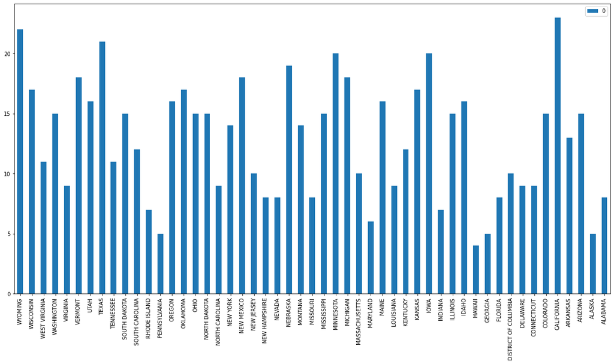

```python
from pandas.core.groupby.groupby import DataFrame
states = list(US_state_polio_incidence.columns)
states.remove('UNITED STATES')

polio_compare_incidence = US_state_polio_incidence[states].div(US_state_polio_incidence['UNITED STATES'], axis=0)

polio_hist = DataFrame()

for state in polio_compare_incidence:
  count = polio_compare_incidence[state][polio_compare_incidence[state] > 1].count()
  polio_hist.insert(0, state, [count])

polio_hist = polio_hist.T

polio_hist.plot.bar(figsize=(20, 10))
```

### Pertussis

```python
#reset index to year for joining
pertussis_incidence.set_index('year', inplace = True)
```

```python
#grab the national incidence and add it into a new dataframe with state incidences
US = pertussis_incidence['incidence']
US_state_pertussis_incidence = states_pertussis_incidence.join(US)
```

```python
#rename column
US_state_pertussis_incidence.rename(columns={'incidence':'UNITED STATES'}, inplace = True)
```

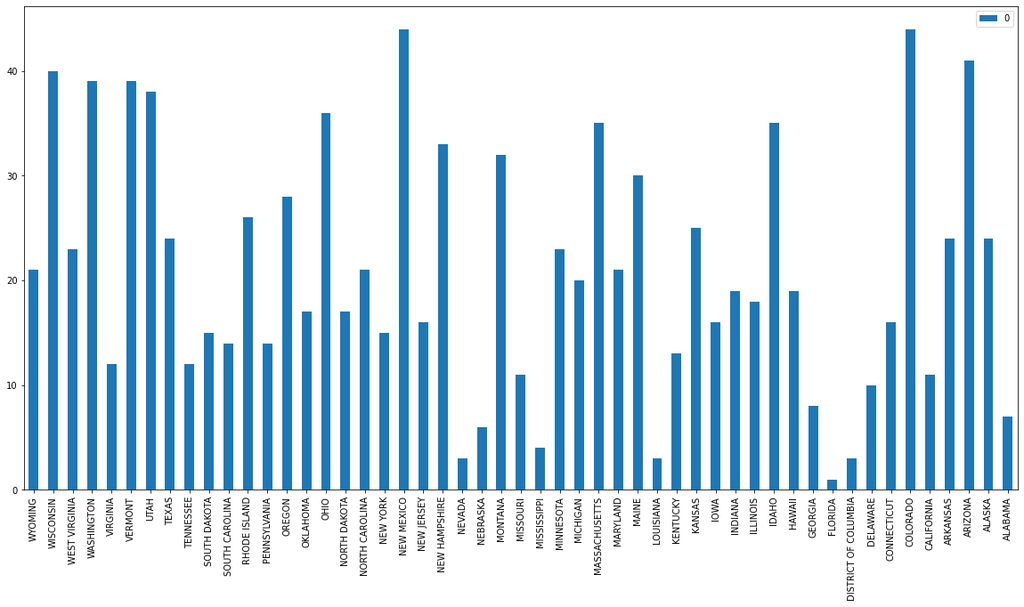

```python
from pandas.core.groupby.groupby import DataFrame
states = list(US_state_pertussis_incidence.columns)
states.remove('UNITED STATES')

pertussis_compare_incidence = US_state_pertussis_incidence[states].div(US_state_pertussis_incidence['UNITED STATES'], axis=0)

pertussis_hist = DataFrame()

for state in pertussis_compare_incidence:
  count = pertussis_compare_incidence[state][pertussis_compare_incidence[state] > 1].count()
  pertussis_hist.insert(0, state, [count])

pertussis_hist = pertussis_hist.T

pertussis_hist.plot.bar(figsize=(20, 10))
```

### Smallpox

```python
#reset index to year for joining
smallpox_incidence.set_index('year', inplace = True)
```

```python
#grab the national incidence and add it into a new dataframe with state incidences
US = smallpox_incidence['incidence']
US_state_smallpox_incidence = states_smallpox_incidence.join(US)
```

```python
#rename column
US_state_smallpox_incidence.rename(columns={'incidence':'UNITED STATES'}, inplace = True)
```

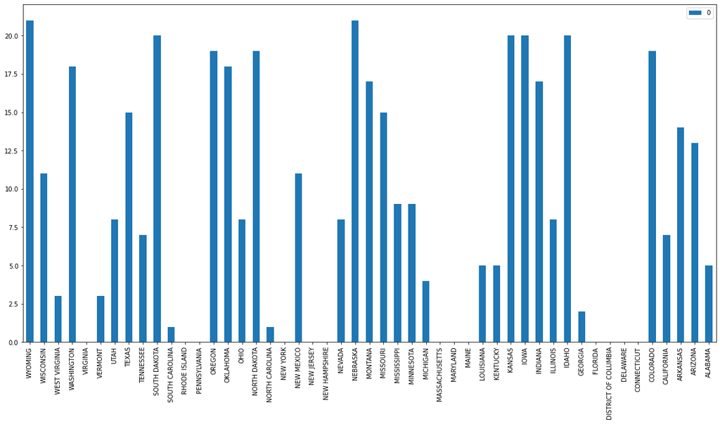

```python
from pandas.core.groupby.groupby import DataFrame
states = list(US_state_smallpox_incidence.columns)
states.remove('UNITED STATES')

smallpox_compare_incidence = US_state_smallpox_incidence[states].div(US_state_smallpox_incidence['UNITED STATES'], axis=0)

smallpox_hist = DataFrame()

for state in smallpox_compare_incidence:
  count = smallpox_compare_incidence[state][smallpox_compare_incidence[state] > 1].count()
  smallpox_hist.insert(0, state, [count])

smallpox_hist = smallpox_hist.T

smallpox_hist.plot.bar(figsize=(20, 10))
```

### Hepatitis A

```python
#reset index to year for joining
hepa_incidence.set_index('year', inplace = True)
```

```python
#grab the national incidence and add it into a new dataframe with state incidences
US = hepa_incidence['incidence']
US_state_hepa_incidence = states_hepa_incidence.join(US)
```

```python
#rename column
US_state_hepa_incidence.rename(columns={'incidence':'UNITED STATES'}, inplace = True)
```

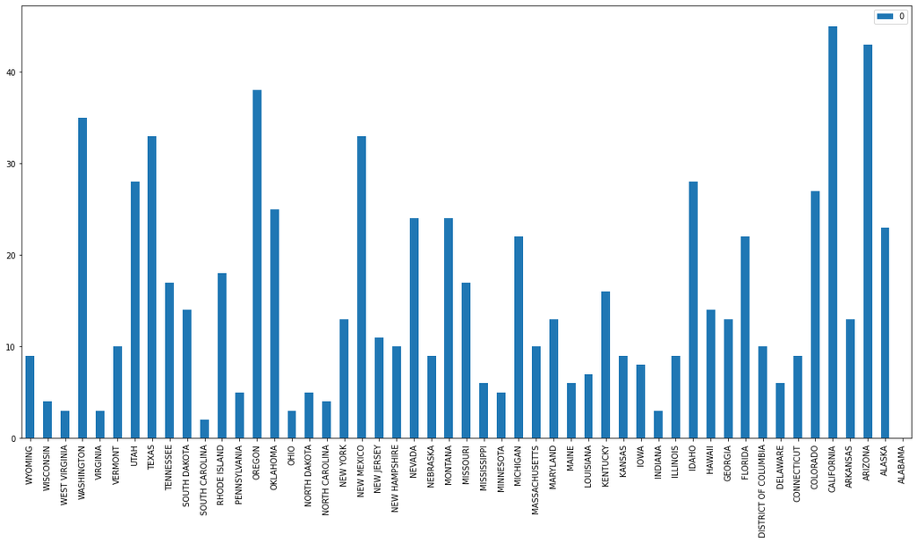

```python
from pandas.core.groupby.groupby import DataFrame
states = list(US_state_hepa_incidence.columns)
states.remove('UNITED STATES')

hepa_compare_incidence = US_state_hepa_incidence[states].div(US_state_hepa_incidence['UNITED STATES'], axis=0)

hepa_hist = DataFrame()

for state in hepa_compare_incidence:
  count = hepa_compare_incidence[state][hepa_compare_incidence[state] > 1].count()
  hepa_hist.insert(0, state, [count])

hepa_hist = hepa_hist.T

hepa_hist.plot.bar(figsize=(20, 10))
```

```python
###
```

### Rubella

```python
#reset index to year for joining
rubella_incidence.set_index('year', inplace = True)
```

```python
#grab the national incidence and add it into a new dataframe with state incidences
US = rubella_incidence['incidence']
US_state_rubella_incidence = states_rubella_incidence.join(US)
```

```python
#rename column
US_state_rubella_incidence.rename(columns={'incidence':'UNITED STATES'}, inplace = True)
```

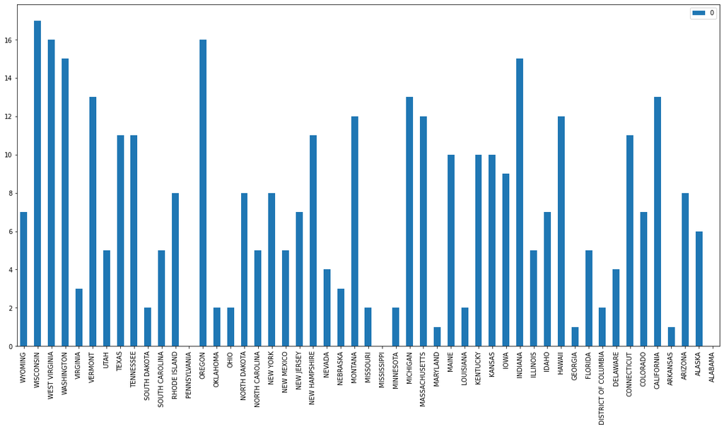

```python
from pandas.core.groupby.groupby import DataFrame
states = list(US_state_rubella_incidence.columns)
states.remove('UNITED STATES')

rubella_compare_incidence = US_state_rubella_incidence[states].div(US_state_rubella_incidence['UNITED STATES'], axis=0)

rubella_hist = DataFrame()

for state in rubella_compare_incidence:
  count = rubella_compare_incidence[state][rubella_compare_incidence[state] > 1].count()
  rubella_hist.insert(0, state, [count])

rubella_hist = rubella_hist.T

rubella_hist.plot.bar(figsize=(20, 10))
```

```python
###
```

### Mumps

```python
#reset index to year for joining
mumps_incidence.set_index('year', inplace = True)
```

```python
#grab the national incidence and add it into a new dataframe with state incidences
US = mumps_incidence['incidence']
US_state_mumps_incidence = states_mumps_incidence.join(US)
```

```python
#rename column
US_state_mumps_incidence.rename(columns={'incidence':'UNITED STATES'}, inplace = True)
```

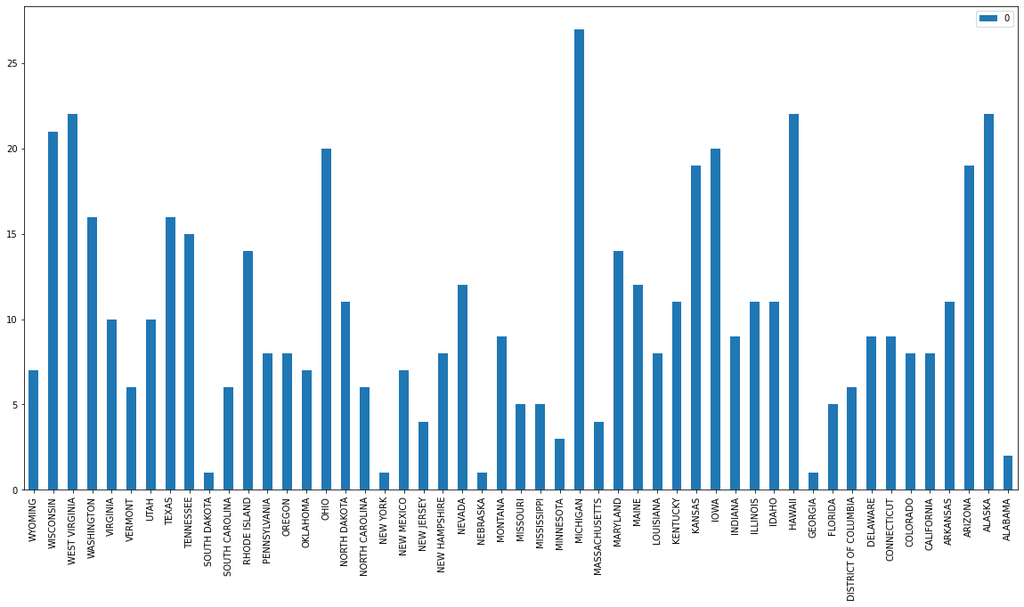

```python
from pandas.core.groupby.groupby import DataFrame
states = list(US_state_mumps_incidence.columns)
states.remove('UNITED STATES')

mumps_compare_incidence = US_state_mumps_incidence[states].div(US_state_mumps_incidence['UNITED STATES'], axis=0)

mumps_hist = DataFrame()

for state in mumps_compare_incidence:
  count = mumps_compare_incidence[state][mumps_compare_incidence[state] > 1].count()
  mumps_hist.insert(0, state, [count])

mumps_hist = mumps_hist.T

mumps_hist.plot.bar(figsize=(20, 10))
```

```python
###
```

## New Data Sets

### Population Density

```python
df_density = pd.read_csv("../finalProject/apportionment.csv", sep=",")

df_density.head()

#grab column names for easy transformation
df_density.columns
#['Name', 'Geography Type', 'Year', 'Resident Population',
       #'Percent Change in Resident Population', 'Resident Population Density',
       #'Resident Population Density Rank', 'Number of Representatives',
       #'Change in Number of Representatives',
       #'Average Apportionment Population Per Representative']

#first we need to get rid of the unnecessary information just to make things cleaner
df_density = df_density.drop(columns=['Resident Population', 'Resident Population Density Rank',
                                      'Percent Change in Resident Population',
                                      'Number of Representatives',	'Change in Number of Representatives',
                                      'Average Apportionment Population Per Representative'])
df_density
```

|  | Name | Geography Type | Year | Resident Population Density |
| --- | --- | --- | --- | --- |
| 0 | Alabama | State | 1910 | 42.2 |
| 1 | Alaska | State | 1910 | 0.1 |
| 2 | Arizona | State | 1910 | 1.8 |
| 3 | Arkansas | State | 1910 | 30.3 |
| 4 | California | State | 1910 | 15.3 |
| ... | ... | ... | ... | ... |
| 679 | Midwest Region | Region | 2020 | NaN |
| 680 | Northeast Region | Region | 2020 | NaN |
| 681 | South Region | Region | 2020 | NaN |
| 682 | West Region | Region | 2020 | NaN |
| 683 | United States | Nation | 2020 | 93.8 |

684 rows × 4 columns

There are also some values within the dataframe that we don't need (at least for initial use with our first dataset) such as the regions and the nationwide information. To change this we can just grab the rows with the type "State"

```python
pop_density = df_density[df_density['Geography Type'] == 'State']
pop_density.drop(pop_density[pop_density['Name'] == 'Puerto Rico'].index, inplace = True)
pop_density
```

|  | Name | Geography Type | Year | Resident Population Density |
| --- | --- | --- | --- | --- |
| 0 | Alabama | State | 1910 | 42.2 |
| 1 | Alaska | State | 1910 | 0.1 |
| 2 | Arizona | State | 1910 | 1.8 |
| 3 | Arkansas | State | 1910 | 30.3 |
| 4 | California | State | 1910 | 15.3 |
| ... | ... | ... | ... | ... |
| 674 | Virginia | State | 2020 | 218.6 |
| 675 | Washington | State | 2020 | 115.9 |
| 676 | West Virginia | State | 2020 | 74.6 |
| 677 | Wisconsin | State | 2020 | 108.8 |
| 678 | Wyoming | State | 2020 | 5.9 |

612 rows × 4 columns

```python
#check the datatypes of the dataset
pop_density.dtypes
```

```
Name                           object
Geography Type                 object
Year                            int64
Resident Population Density    object
dtype: object
```

```python
#change the resident population density to a float
pop_density['Resident Population Density'] = pd.to_numeric(pop_density['Resident Population Density'],errors='coerce')

pop_density['Resident Population Density'].describe()
```

```
count    592.000000
mean     122.555912
std      175.061531
min        0.100000
25%       23.450000
50%       56.900000
75%      138.000000
max      974.700000
Name: Resident Population Density, dtype: float64
```

```python
#We also need to make the states uppercase for easu combining later

pop_density['Name'] = pop_density['Name'].str.upper()

pop_density.head()
```

|  | Name | Geography Type | Year | Resident Population Density |
| --- | --- | --- | --- | --- |
| 0 | ALABAMA | State | 1910 | 42.2 |
| 1 | ALASKA | State | 1910 | 0.1 |
| 2 | ARIZONA | State | 1910 | 1.8 |
| 3 | ARKANSAS | State | 1910 | 30.3 |
| 4 | CALIFORNIA | State | 1910 | 15.3 |

The final step to combining this with the initial disease dataset is to ensure that all of the years present in the disease dataset also exist in the population density dataset. This data is grabbed from the census so there are only reports for the 1st year of every decade. While not exact, we can fill in the expected density for each year based on the values provided for each decade. This is done by creating rows for each year and then using interpolate to fill in NaN values by approximating them.

```python
#create list of years needed to fill in the population density data frame
years = list(range(1911, 2020, 1))


years.remove(1920)
years.remove(1930)
years.remove(1940)
years.remove(1950)
years.remove(1960)
years.remove(1970)
years.remove(1980)
years.remove(1990)
years.remove(2000)

years

#itereate over populaiton density to create and fill in a dataframe for each state
states_density = dict()
for k, v in pop_density.groupby('Name'):
  states_density[k] = v
  for year in years:
    states_density[k] = states_density[k].append({'Name':k,	'Geography Type':'State',	'Year':year}, ignore_index=True)
  states_density[k].sort_values(by = 'Year', inplace = True)
```

```python
#use interpolate to approximate population density for each year in each state.
for frame in states_density:
    states_density[frame].interpolate(method='linear', column = 'Resident Population Density', inplace=True)
```

Next step for these datasets would be to combine them with the disease datasets and begin measuring corellation between population density and incidence for each disease. We are experiencing trouble with the actual joiningthe two datasets and will likely need to perform further transformations to make this possible cleanly. Currently though, we have 2 dictionaries of datasets - 1 for the population density every year by state, and 1 for the disease incidence every year by state. We would expect to see a correlation between higher population density and higher incidence rates, so it will be interesting exploring that. We have more details surrounding this in our plans for the model below.

# Income Level

We will attempt to investigate whether average income level by state has any correlation with the disease prevalence by state.

Data source: https://apps.bea.gov/iTable/?reqid=70&step=1&acrdn=2#eyJhcHBpZCI6NzAsInN0ZXBzIjpbMSwyNCwyOSwyNSwzMSwyNiwyNywzMF0s…

```python
income_df = pd.read_csv("../finalProject/income.csv", sep=",", skiprows = 3)
#reading in income file as a dataframe
#we need to skip the first 3 rows because there are some text explanations written in these rows

income_df
#original dataframe
```

|  | GeoFips | GeoName | 1929 | 1930 | 1931 | 1932 | 1933 | 1934 | 1935 | 1936 | ... | 2012 | 2013 | 2014 | 2015 | 2016 | 2017 | 2018 | 2019 | 2020 | 2021 |
| --- | --- | --- | --- | --- | --- | --- | --- | --- | --- | --- | --- | --- | --- | --- | --- | --- | --- | --- | --- | --- | --- |
| 0 | 00000 | United States | 85151.0 | 76394.0 | 65531.0 | 50162.0 | 47114.0 | 53967.0 | 60704.0 | 69063.0 | ... | 14003346.0 | 14189228.0 | 14969527.0 | 15681233.0 | 16092713.0 | 16837337.0 | 17671054.0 | 18575467.0 | 19812171.0 | 21288709.0 |
| 1 | 01000 | Alabama | 843.2 | 697.5 | 583.7 | 421.9 | 435.6 | 556.3 | 586.9 | 683.2 | ... | 173361.7 | 175185.3 | 181078.8 | 189115.4 | 192363.5 | 199191.8 | 206712.0 | 216587.5 | 232040.3 | 250828.8 |
| 2 | 02000 | Alaska * | (NA) | (NA) | (NA) | (NA) | (NA) | (NA) | (NA) | (NA) | ... | 39266.0 | 38978.0 | 41210.0 | 42555.1 | 41837.4 | 42431.4 | 43981.2 | 45056.8 | 45965.1 | 48219.2 |
| 3 | 04000 | Arizona | 257.3 | 224.7 | 184.5 | 137.0 | 131.8 | 154.9 | 180.4 | 204.8 | ... | 237809.1 | 243752.3 | 257272.3 | 270815.5 | 282085.1 | 299249.2 | 316896.3 | 340259.8 | 375601.3 | 403739.3 |
| 4 | 05000 | Arkansas | 560.4 | 416.5 | 381.8 | 278.5 | 283.2 | 341.8 | 386.0 | 460.2 | ... | 107877.3 | 108367.8 | 114743.3 | 118719.5 | 121825.9 | 125285.9 | 130033.4 | 133161.4 | 142038.5 | 153185.8 |
| ... | ... | ... | ... | ... | ... | ... | ... | ... | ... | ... | ... | ... | ... | ... | ... | ... | ... | ... | ... | ... | ... |
| 60 | Legend/Footnotes | NaN | NaN | NaN | NaN | NaN | NaN | NaN | NaN | NaN | ... | NaN | NaN | NaN | NaN | NaN | NaN | NaN | NaN | NaN | NaN |
| 61 | * Estimates prior to 1950 are not available fo... | NaN | NaN | NaN | NaN | NaN | NaN | NaN | NaN | NaN | ... | NaN | NaN | NaN | NaN | NaN | NaN | NaN | NaN | NaN | NaN |
| 62 | Note. All dollar estimates are in millions of ... | NaN | NaN | NaN | NaN | NaN | NaN | NaN | NaN | NaN | ... | NaN | NaN | NaN | NaN | NaN | NaN | NaN | NaN | NaN | NaN |
| 63 | (NA) Not available. | NaN | NaN | NaN | NaN | NaN | NaN | NaN | NaN | NaN | ... | NaN | NaN | NaN | NaN | NaN | NaN | NaN | NaN | NaN | NaN |
| 64 | Last updated: September 30, 2022--revised st... | NaN | NaN | NaN | NaN | NaN | NaN | NaN | NaN | NaN | ... | NaN | NaN | NaN | NaN | NaN | NaN | NaN | NaN | NaN | NaN |

65 rows × 95 columns

**Data Filtering**

We do not have a use for the GeoFips column, which is just the geo-codes corresponding to each state. We also need to get rid of the footnote rows at the bottom of the document.

The datasource notes that estimates prior to 1950 are not available for Alaska and Hawaii.

```python
import numpy as np
income_df
#income_df.drop(income_df[(income_df['GeoFips'] == object)].index, inplace=True)

income_df = income_df[0:60]
#We only want to keep the first 60 rows because there are unnecessary lines at the end.

income_df.drop(columns = ["GeoFips"], inplace=True)
#We don't care about the GeoFips column

#We want to change the names that have asterisks to make the data look nicer
income_df['GeoName'].loc[income_df['GeoName'].isin(['Alaska *'])] = 'Alaska'
income_df['GeoName'].loc[income_df['GeoName'].isin(['Hawaii *'])] = 'Hawaii'

income_df = income_df.replace('(NA)', np.nan)
#Replacing NA values with NaN

income_df.isnull().sum()[income_df.isnull().sum() > 2]
#Since we know from the data source that 2 states do not have values before 1950, we check to see if there are any other missing values from the other 48 states.
#We see that we return an empty series, so that means only two states had NaN's like we expected.
```

```
Series([], dtype: int64)
```

Now we display the resulting dataset after this cleanup:

```python
income_df #resulting dataset
```

|  | GeoName | 1929 | 1930 | 1931 | 1932 | 1933 | 1934 | 1935 | 1936 | 1937 | ... | 2012 | 2013 | 2014 | 2015 | 2016 | 2017 | 2018 | 2019 | 2020 | 2021 |
| --- | --- | --- | --- | --- | --- | --- | --- | --- | --- | --- | --- | --- | --- | --- | --- | --- | --- | --- | --- | --- | --- |
| 0 | United States | 85151.0 | 76394.0 | 65531.0 | 50162.0 | 47114.0 | 53967.0 | 60704.0 | 69063.0 | 74556.0 | ... | 14003346.0 | 14189228.0 | 14969527.0 | 15681233.0 | 16092713.0 | 16837337.0 | 17671054.0 | 18575467.0 | 19812171.0 | 21288709.0 |
| 1 | Alabama | 843.2 | 697.5 | 583.7 | 421.9 | 435.6 | 556.3 | 586.9 | 683.2 | 733.7 | ... | 173361.7 | 175185.3 | 181078.8 | 189115.4 | 192363.5 | 199191.8 | 206712.0 | 216587.5 | 232040.3 | 250828.8 |
| 2 | Alaska | NaN | NaN | NaN | NaN | NaN | NaN | NaN | NaN | NaN | ... | 39266.0 | 38978.0 | 41210.0 | 42555.1 | 41837.4 | 42431.4 | 43981.2 | 45056.8 | 45965.1 | 48219.2 |
| 3 | Arizona | 257.3 | 224.7 | 184.5 | 137.0 | 131.8 | 154.9 | 180.4 | 204.8 | 229.0 | ... | 237809.1 | 243752.3 | 257272.3 | 270815.5 | 282085.1 | 299249.2 | 316896.3 | 340259.8 | 375601.3 | 403739.3 |
| 4 | Arkansas | 560.4 | 416.5 | 381.8 | 278.5 | 283.2 | 341.8 | 386.0 | 460.2 | 481.6 | ... | 107877.3 | 108367.8 | 114743.3 | 118719.5 | 121825.9 | 125285.9 | 130033.4 | 133161.4 | 142038.5 | 153185.8 |
| 5 | California | 5495.5 | 5079.4 | 4387.5 | 3441.4 | 3277.3 | 3666.5 | 4107.3 | 4923.2 | 5231.8 | ... | 1827166.9 | 1857200.9 | 1980736.8 | 2125430.3 | 2218457.8 | 2318280.9 | 2431773.9 | 2567425.6 | 2790523.5 | 3006183.9 |
| 6 | Colorado | 635.6 | 596.8 | 498.5 | 380.3 | 378.4 | 399.5 | 480.0 | 590.4 | 589.5 | ... | 236759.1 | 249512.7 | 271410.2 | 284836.8 | 289673.0 | 309417.3 | 331851.0 | 356341.3 | 378051.4 | 410948.2 |
| 7 | Connecticut | 1640.5 | 1494.7 | 1313.1 | 1026.9 | 970.3 | 1091.2 | 1191.0 | 1362.2 | 1459.3 | ... | 231171.1 | 226175.8 | 236756.6 | 243164.6 | 247777.4 | 252571.3 | 263357.6 | 272459.4 | 282486.1 | 300323.5 |
| 8 | Delaware | 243.4 | 205.1 | 187.7 | 144.9 | 140.4 | 161.8 | 177.9 | 220.5 | 242.7 | ... | 40393.3 | 41100.3 | 43031.6 | 45216.1 | 46444.8 | 48476.2 | 51191.2 | 53202.5 | 55866.8 | 60133.6 |
| 9 | District of Columbia | 639.3 | 641.4 | 631.7 | 567.9 | 500.2 | 547.2 | 626.8 | 719.0 | 745.7 | ... | 43010.6 | 43697.3 | 46780.2 | 50337.3 | 52684.5 | 54464.8 | 56707.5 | 58203.2 | 61925.5 | 64644.7 |
| 10 | Florida | 749.9 | 688.0 | 592.6 | 482.4 | 448.4 | 551.8 | 610.4 | 748.6 | 838.9 | ... | 800551.7 | 802975.7 | 861412.3 | 919834.9 | 954069.7 | 1023855.3 | 1088794.7 | 1165093.1 | 1235793.4 | 1356318.6 |
| 11 | Georgia | 995.6 | 881.8 | 741.9 | 578.8 | 595.6 | 715.2 | 789.8 | 893.7 | 948.2 | ... | 371456.8 | 377202.2 | 402790.9 | 427437.4 | 444023.7 | 469213.5 | 493507.4 | 522393.0 | 557601.2 | 602464.0 |
| 12 | Hawaii | NaN | NaN | NaN | NaN | NaN | NaN | NaN | NaN | NaN | ... | 61557.0 | 62521.2 | 66036.7 | 69109.1 | 71571.7 | 74542.8 | 76168.3 | 79699.7 | 83109.5 | 87857.7 |
| 13 | Idaho | 223.2 | 218.2 | 166.3 | 122.9 | 105.8 | 183.8 | 189.4 | 230.7 | 213.5 | ... | 56177.1 | 58403.7 | 61801.4 | 65475.7 | 68009.3 | 71888.4 | 76435.2 | 83031.5 | 91448.5 | 99549.6 |
| 14 | Illinois | 7229.8 | 6190.9 | 5171.8 | 3783.0 | 3422.7 | 3949.2 | 4494.9 | 5127.6 | 5764.7 | ... | 595073.5 | 609778.6 | 638640.0 | 666943.7 | 673691.0 | 692895.9 | 728667.0 | 750935.6 | 794459.5 | 852082.1 |
| 15 | Indiana | 1950.4 | 1660.6 | 1415.9 | 1012.0 | 971.0 | 1186.3 | 1397.6 | 1610.8 | 1842.5 | ... | 258136.4 | 261702.3 | 272244.9 | 282821.4 | 290604.4 | 300964.6 | 315740.4 | 329625.0 | 354337.7 | 384520.0 |
| 16 | Iowa | 1404.0 | 1239.1 | 983.4 | 728.9 | 629.6 | 680.8 | 1054.6 | 981.2 | 1282.6 | ... | 132158.9 | 134757.8 | 139531.3 | 144587.6 | 145790.0 | 149420.3 | 155916.4 | 160360.6 | 169994.2 | 182524.5 |
| 17 | Kansas | 982.6 | 866.3 | 741.6 | 502.8 | 470.6 | 537.6 | 674.3 | 722.6 | 792.9 | ... | 130948.1 | 133979.9 | 136878.7 | 138336.8 | 138533.9 | 142421.6 | 148523.2 | 155125.9 | 164333.6 | 172918.3 |
| 18 | Kentucky | 1010.8 | 844.7 | 760.9 | 558.2 | 549.9 | 630.7 | 726.4 | 810.9 | 943.0 | ... | 157635.7 | 159224.8 | 166717.1 | 174331.2 | 177190.6 | 182391.5 | 188348.3 | 197356.0 | 214052.5 | 231179.8 |
| 19 | Louisiana | 852.8 | 743.1 | 670.0 | 513.1 | 491.7 | 579.8 | 644.1 | 737.5 | 795.3 | ... | 188760.8 | 191497.3 | 200293.9 | 201363.5 | 200190.6 | 206121.5 | 215086.4 | 222349.1 | 236324.2 | 250700.7 |
| 20 | Maine | 477.9 | 458.9 | 397.3 | 309.9 | 306.6 | 346.9 | 363.7 | 427.6 | 432.5 | ... | 53782.5 | 53742.0 | 55863.6 | 58331.3 | 59959.2 | 62372.1 | 65015.1 | 68863.0 | 74805.9 | 80254.4 |
| 21 | Maryland | 1257.0 | 1179.3 | 1071.1 | 876.0 | 804.1 | 908.9 | 965.2 | 1093.6 | 1183.0 | ... | 312175.8 | 311524.0 | 322438.2 | 337702.8 | 350384.4 | 361606.2 | 371870.3 | 384074.3 | 405454.6 | 430429.3 |
| 22 | Massachusetts | 3853.4 | 3578.6 | 3254.4 | 2648.8 | 2430.4 | 2658.8 | 2835.6 | 3155.6 | 3235.7 | ... | 379267.8 | 382611.1 | 401832.5 | 428228.9 | 444184.1 | 463980.9 | 487436.5 | 513710.4 | 550459.5 | 584291.1 |
| 23 | Michigan | 3796.8 | 3178.9 | 2593.3 | 1885.8 | 1661.4 | 2179.6 | 2571.8 | 3035.3 | 3415.4 | ... | 389544.1 | 393576.8 | 411019.8 | 433688.6 | 446030.2 | 459437.9 | 477925.4 | 495268.6 | 537493.5 | 567807.1 |
| 24 | Minnesota | 1528.9 | 1409.5 | 1194.0 | 956.4 | 829.2 | 968.1 | 1219.3 | 1294.6 | 1477.3 | ... | 257164.2 | 259781.8 | 273488.0 | 286422.9 | 292234.9 | 304179.5 | 319452.6 | 332916.0 | 355211.2 | 378284.7 |
| 25 | Mississippi | 552.9 | 396.0 | 337.6 | 244.9 | 257.1 | 342.6 | 358.9 | 460.9 | 458.3 | ... | 100377.2 | 102317.4 | 104255.5 | 106064.0 | 107499.5 | 110093.1 | 112739.0 | 117112.8 | 126306.9 | 135347.4 |
| 26 | Missouri | 2241.6 | 2042.5 | 1815.3 | 1366.8 | 1261.9 | 1392.8 | 1597.7 | 1775.7 | 1926.6 | ... | 242981.4 | 245200.0 | 254317.5 | 263271.4 | 270603.5 | 276573.9 | 288564.8 | 301030.7 | 320698.2 | 341254.0 |
| 27 | Montana | 310.3 | 270.0 | 208.8 | 180.6 | 161.8 | 198.9 | 261.2 | 265.0 | 284.6 | ... | 40919.7 | 41322.5 | 43555.8 | 45453.5 | 46074.1 | 48704.8 | 50780.1 | 54083.5 | 58769.6 | 62886.7 |
| 28 | Nebraska | 803.0 | 704.1 | 566.1 | 419.4 | 378.6 | 364.7 | 556.2 | 535.8 | 554.0 | ... | 86754.2 | 87398.7 | 92524.0 | 96282.1 | 94838.0 | 96996.2 | 100995.1 | 105922.2 | 112629.7 | 120188.5 |
| 29 | Nevada | 78.6 | 76.7 | 62.5 | 53.5 | 47.9 | 54.9 | 66.7 | 85.3 | 79.8 | ... | 109347.4 | 109870.5 | 117372.2 | 127117.0 | 132058.4 | 140347.5 | 149611.8 | 161433.6 | 172538.5 | 189308.2 |
| 30 | New Hampshire | 321.3 | 301.9 | 263.3 | 203.8 | 200.5 | 230.3 | 242.2 | 260.6 | 274.3 | ... | 67855.3 | 67703.7 | 70501.2 | 73474.6 | 76092.3 | 79312.5 | 83026.0 | 88822.8 | 94440.8 | 101674.5 |
| 31 | New Jersey | 3673.7 | 3461.9 | 3054.6 | 2443.2 | 2171.3 | 2363.9 | 2578.6 | 2920.2 | 3079.3 | ... | 487527.7 | 492488.2 | 515515.1 | 537105.9 | 552051.4 | 573105.5 | 598428.7 | 633651.0 | 663544.1 | 713720.6 |
| 32 | New Mexico | 170.2 | 142.0 | 125.0 | 91.9 | 94.6 | 113.6 | 139.4 | 167.6 | 182.2 | ... | 74725.4 | 73561.8 | 77975.1 | 79864.3 | 81414.1 | 82903.6 | 86685.6 | 91853.6 | 99018.0 | 106451.2 |
| 33 | New York | 14071.1 | 13171.9 | 11416.2 | 8921.7 | 8327.9 | 9117.2 | 9790.3 | 11041.1 | 11460.0 | ... | 1049158.2 | 1062135.4 | 1105907.8 | 1154722.9 | 1194534.6 | 1270251.6 | 1311427.5 | 1362298.6 | 1442624.6 | 1524128.5 |
| 34 | North Carolina | 1024.0 | 909.4 | 776.8 | 591.2 | 663.5 | 816.0 | 888.8 | 982.5 | 1086.2 | ... | 380160.6 | 376392.4 | 398099.5 | 419334.3 | 432626.2 | 453729.2 | 476308.7 | 505470.2 | 542726.5 | 592695.0 |
| 35 | North Dakota | 254.0 | 210.1 | 132.3 | 120.3 | 101.7 | 123.9 | 181.3 | 158.0 | 212.2 | ... | 39796.2 | 39933.5 | 42819.6 | 41178.9 | 39765.8 | 40266.3 | 42733.1 | 44346.9 | 47410.7 | 50002.9 |
| 36 | Ohio | 5113.9 | 4421.8 | 3772.0 | 2704.2 | 2608.5 | 3083.1 | 3520.0 | 4060.5 | 4434.3 | ... | 471703.9 | 479088.7 | 498894.6 | 518826.8 | 529069.6 | 547516.6 | 568458.4 | 589835.8 | 631330.7 | 670035.6 |
| 37 | Oklahoma | 1065.6 | 876.0 | 706.3 | 511.4 | 525.5 | 598.9 | 707.4 | 761.9 | 874.5 | ... | 161128.4 | 169382.6 | 180469.0 | 175134.0 | 166547.7 | 174159.6 | 182341.2 | 191851.6 | 200152.9 | 214760.7 |
| 38 | Oregon | 630.4 | 578.3 | 486.4 | 366.8 | 349.3 | 430.2 | 459.9 | 560.2 | 582.7 | ... | 153548.0 | 156130.0 | 167077.3 | 179600.2 | 188283.3 | 198957.5 | 211541.6 | 222257.0 | 241790.3 | 261546.5 |
| 39 | Pennsylvania | 7545.0 | 6915.9 | 5869.1 | 4442.9 | 4137.0 | 4770.6 | 5120.2 | 5937.4 | 6299.4 | ... | 587666.0 | 593682.1 | 619079.4 | 643988.1 | 661160.1 | 678604.6 | 714331.5 | 739891.8 | 788281.5 | 833314.5 |
| 40 | Rhode Island | 602.8 | 545.2 | 489.1 | 395.1 | 383.8 | 411.0 | 444.0 | 494.8 | 514.9 | ... | 48501.7 | 48544.7 | 50646.2 | 52447.6 | 53229.7 | 55310.7 | 57490.5 | 61107.2 | 65709.0 | 70531.5 |
| 41 | South Carolina | 464.7 | 417.2 | 355.8 | 273.5 | 301.7 | 364.6 | 402.8 | 456.0 | 488.7 | ... | 169185.2 | 171617.2 | 182832.6 | 194364.1 | 202215.4 | 212325.2 | 221707.2 | 237024.5 | 251946.2 | 272339.5 |
| 42 | South Dakota | 286.2 | 247.3 | 167.8 | 130.9 | 93.9 | 129.3 | 205.6 | 164.9 | 210.5 | ... | 37844.2 | 38365.9 | 40252.3 | 41912.7 | 42336.8 | 43599.0 | 45660.9 | 48797.0 | 53621.5 | 57717.8 |
| 43 | Tennessee | 971.2 | 841.9 | 724.9 | 526.2 | 552.6 | 674.5 | 735.1 | 844.4 | 927.9 | ... | 254470.6 | 256753.8 | 267288.7 | 281281.1 | 290239.9 | 302461.6 | 319022.2 | 338609.2 | 362278.1 | 394520.4 |
| 44 | Texas | 2728.7 | 2381.2 | 2038.5 | 1560.7 | 1530.0 | 1763.9 | 1989.8 | 2301.7 | 2613.6 | ... | 1152725.2 | 1184840.5 | 1274636.9 | 1300510.1 | 1296480.8 | 1387922.6 | 1482714.1 | 1560503.5 | 1624525.8 | 1767681.7 |
| 45 | Utah | 278.2 | 251.6 | 190.8 | 157.4 | 154.6 | 163.9 | 205.5 | 243.8 | 236.5 | ... | 102990.8 | 106176.2 | 112620.2 | 121339.2 | 127881.4 | 135162.2 | 145255.8 | 157045.2 | 171385.4 | 186990.5 |
| 46 | Vermont | 226.3 | 206.0 | 169.2 | 129.9 | 120.4 | 136.2 | 148.0 | 167.7 | 172.7 | ... | 28554.4 | 28964.3 | 30195.9 | 31079.0 | 31575.6 | 32445.5 | 33577.0 | 35584.5 | 38097.7 | 39949.4 |
| 47 | Virginia | 1054.5 | 938.4 | 906.9 | 701.9 | 704.4 | 801.9 | 891.2 | 1004.3 | 1104.1 | ... | 404179.7 | 401684.3 | 419329.6 | 438272.8 | 449830.1 | 466610.7 | 483922.1 | 507874.1 | 536817.2 | 573027.9 |
| 48 | Washington | 1150.5 | 1030.7 | 844.7 | 637.4 | 598.8 | 712.4 | 799.6 | 942.3 | 1009.8 | ... | 326698.8 | 333763.7 | 359690.6 | 381158.1 | 401774.3 | 426442.7 | 454583.5 | 490322.1 | 527581.8 | 570920.8 |
| 49 | West Virginia | 787.4 | 706.1 | 616.3 | 448.2 | 453.0 | 554.0 | 606.3 | 707.2 | 760.3 | ... | 65898.5 | 65572.8 | 67764.4 | 69178.6 | 68630.1 | 71344.5 | 74740.0 | 77329.9 | 80971.2 | 86451.8 |
| 50 | Wisconsin | 1966.8 | 1724.7 | 1402.6 | 1094.0 | 1014.1 | 1160.9 | 1415.6 | 1596.7 | 1702.8 | ... | 246242.3 | 247847.4 | 258347.8 | 269703.9 | 274374.7 | 284576.5 | 298256.9 | 311019.0 | 329622.8 | 351551.3 |
| 51 | Wyoming | 149.9 | 131.6 | 109.3 | 86.4 | 85.5 | 96.4 | 118.1 | 132.5 | 147.2 | ... | 31199.6 | 31240.1 | 33549.3 | 33761.8 | 31908.5 | 32952.3 | 34759.6 | 36889.0 | 37974.0 | 40322.8 |
| 52 | New England | 7122.1 | 6585.3 | 5886.4 | 4714.4 | 4411.9 | 4874.4 | 5224.5 | 5868.5 | 6089.4 | ... | 809132.8 | 807741.7 | 845796.0 | 886726.0 | 912818.4 | 945992.9 | 989902.7 | 1040547.3 | 1105999.0 | 1177024.3 |
| 53 | Mideast | 27429.4 | 25575.4 | 22230.5 | 17396.5 | 16080.9 | 17869.6 | 19258.9 | 21931.8 | 23010.1 | ... | 2519931.4 | 2544627.4 | 2652752.3 | 2769073.0 | 2857259.7 | 2986508.9 | 3103956.7 | 3231321.4 | 3417697.1 | 3626371.3 |
| 54 | Great Lakes | 20057.6 | 17176.9 | 14355.4 | 10479.1 | 9677.7 | 11559.0 | 13400.0 | 15431.0 | 17159.7 | ... | 1960700.3 | 1991993.7 | 2079147.1 | 2171984.3 | 2213769.8 | 2285391.6 | 2389048.1 | 2476684.1 | 2647244.2 | 2825996.1 |
| 55 | Plains | 7500.3 | 6718.8 | 5600.5 | 4225.6 | 3765.5 | 4197.0 | 5489.1 | 5632.8 | 6456.0 | ... | 927647.3 | 939417.7 | 979811.3 | 1011992.5 | 1024103.0 | 1053457.0 | 1101846.0 | 1148499.4 | 1223899.1 | 1302890.5 |
| 56 | Southeast | 9867.4 | 8480.3 | 7449.1 | 5618.7 | 5736.6 | 6929.2 | 7626.7 | 8789.5 | 9566.2 | ... | 3173915.8 | 3188790.8 | 3366606.7 | 3539296.7 | 3640705.1 | 3822623.9 | 4010921.4 | 4240360.9 | 4518896.1 | 4899059.8 |
| 57 | Southwest | 4221.8 | 3624.0 | 3054.4 | 2301.0 | 2281.9 | 2631.3 | 3017.0 | 3436.0 | 3899.2 | ... | 1626388.0 | 1671537.2 | 1790353.2 | 1826323.9 | 1826527.7 | 1944234.9 | 2068637.2 | 2184468.5 | 2299298.0 | 2492632.8 |
| 58 | Rocky Mountain | 1597.2 | 1468.1 | 1173.7 | 927.5 | 886.2 | 1042.6 | 1254.3 | 1462.3 | 1471.3 | ... | 468046.3 | 486655.2 | 522936.8 | 550866.9 | 563546.4 | 598125.1 | 639081.5 | 687390.6 | 737628.9 | 800697.9 |
| 59 | Far West | 7355.1 | 6765.2 | 5781.1 | 4499.1 | 4273.4 | 4863.9 | 5433.5 | 6511.0 | 6904.1 | ... | 2517584.1 | 2558464.3 | 2732123.7 | 2924969.8 | 3053982.8 | 3201002.7 | 3367660.3 | 3566194.8 | 3861508.7 | 4164036.4 |

60 rows × 94 columns

Now we need to complete some transformations to prepare the dataset for analysis.

```python
income_df1 = income_df.set_index('GeoName') #reset index to be by state
income_dfT1 = income_df1.T #transpose
income_dfT1.reset_index(inplace=True) #adding year back as a column to use for plotting
income_dfT1.columns = income_dfT1.columns.str.upper() #need these to be uppercase to join with population density dataset
income_dfT1.rename(columns={'INDEX':'year'}, inplace=True) #renaming column to make more clear
income_dfT1
```

| GeoName | year | UNITED STATES | ALABAMA | ALASKA | ARIZONA | ARKANSAS | CALIFORNIA | COLORADO | CONNECTICUT | DELAWARE | ... | WISCONSIN | WYOMING | NEW ENGLAND | MIDEAST | GREAT LAKES | PLAINS | SOUTHEAST | SOUTHWEST | ROCKY MOUNTAIN | FAR WEST |
| --- | --- | --- | --- | --- | --- | --- | --- | --- | --- | --- | --- | --- | --- | --- | --- | --- | --- | --- | --- | --- | --- |
| 0 | 1929 | 85151.0 | 843.2 | NaN | 257.3 | 560.4 | 5495.5 | 635.6 | 1640.5 | 243.4 | ... | 1966.8 | 149.9 | 7122.1 | 27429.4 | 20057.6 | 7500.3 | 9867.4 | 4221.8 | 1597.2 | 7355.1 |
| 1 | 1930 | 76394.0 | 697.5 | NaN | 224.7 | 416.5 | 5079.4 | 596.8 | 1494.7 | 205.1 | ... | 1724.7 | 131.6 | 6585.3 | 25575.4 | 17176.9 | 6718.8 | 8480.3 | 3624.0 | 1468.1 | 6765.2 |
| 2 | 1931 | 65531.0 | 583.7 | NaN | 184.5 | 381.8 | 4387.5 | 498.5 | 1313.1 | 187.7 | ... | 1402.6 | 109.3 | 5886.4 | 22230.5 | 14355.4 | 5600.5 | 7449.1 | 3054.4 | 1173.7 | 5781.1 |
| 3 | 1932 | 50162.0 | 421.9 | NaN | 137.0 | 278.5 | 3441.4 | 380.3 | 1026.9 | 144.9 | ... | 1094.0 | 86.4 | 4714.4 | 17396.5 | 10479.1 | 4225.6 | 5618.7 | 2301.0 | 927.5 | 4499.1 |
| 4 | 1933 | 47114.0 | 435.6 | NaN | 131.8 | 283.2 | 3277.3 | 378.4 | 970.3 | 140.4 | ... | 1014.1 | 85.5 | 4411.9 | 16080.9 | 9677.7 | 3765.5 | 5736.6 | 2281.9 | 886.2 | 4273.4 |
| ... | ... | ... | ... | ... | ... | ... | ... | ... | ... | ... | ... | ... | ... | ... | ... | ... | ... | ... | ... | ... | ... |
| 88 | 2017 | 16837337.0 | 199191.8 | 42431.4 | 299249.2 | 125285.9 | 2318280.9 | 309417.3 | 252571.3 | 48476.2 | ... | 284576.5 | 32952.3 | 945992.9 | 2986508.9 | 2285391.6 | 1053457.0 | 3822623.9 | 1944234.9 | 598125.1 | 3201002.7 |
| 89 | 2018 | 17671054.0 | 206712.0 | 43981.2 | 316896.3 | 130033.4 | 2431773.9 | 331851.0 | 263357.6 | 51191.2 | ... | 298256.9 | 34759.6 | 989902.7 | 3103956.7 | 2389048.1 | 1101846.0 | 4010921.4 | 2068637.2 | 639081.5 | 3367660.3 |
| 90 | 2019 | 18575467.0 | 216587.5 | 45056.8 | 340259.8 | 133161.4 | 2567425.6 | 356341.3 | 272459.4 | 53202.5 | ... | 311019.0 | 36889.0 | 1040547.3 | 3231321.4 | 2476684.1 | 1148499.4 | 4240360.9 | 2184468.5 | 687390.6 | 3566194.8 |
| 91 | 2020 | 19812171.0 | 232040.3 | 45965.1 | 375601.3 | 142038.5 | 2790523.5 | 378051.4 | 282486.1 | 55866.8 | ... | 329622.8 | 37974.0 | 1105999.0 | 3417697.1 | 2647244.2 | 1223899.1 | 4518896.1 | 2299298.0 | 737628.9 | 3861508.7 |
| 92 | 2021 | 21288709.0 | 250828.8 | 48219.2 | 403739.3 | 153185.8 | 3006183.9 | 410948.2 | 300323.5 | 60133.6 | ... | 351551.3 | 40322.8 | 1177024.3 | 3626371.3 | 2825996.1 | 1302890.5 | 4899059.8 | 2492632.8 | 800697.9 | 4164036.4 |

93 rows × 61 columns

We need to check that the datatypes are correct.

```python
income_dfT1.dtypes
```

```
GeoName
year              object
UNITED STATES     object
ALABAMA           object
ALASKA            object
ARIZONA           object
                   ...
PLAINS            object
SOUTHEAST         object
SOUTHWEST         object
ROCKY MOUNTAIN    object
FAR WEST          object
Length: 61, dtype: object
```

Oops! These are all objects, when we expect integers for years and floats for the income amounts.

```python
cols_income = income_dfT1.columns
income_dfT1[cols_income] = income_dfT1[cols_income].apply(pd.to_numeric, errors='coerce') #changing datatypes from objects to floats/integers where appropriate

income_dfT1['ARIZONA'] #checking datatype
```

```
0        257.3
1        224.7
2        184.5
3        137.0
4        131.8
        ...
88    299249.2
89    316896.3
90    340259.8
91    375601.3
92    403739.3
Name: ARIZONA, Length: 93, dtype: float64
```

```python
income_dfT1.dtypes
```

```
GeoName
year                int64
UNITED STATES     float64
ALABAMA           float64
ALASKA            float64
ARIZONA           float64
                   ...
PLAINS            float64
SOUTHEAST         float64
SOUTHWEST         float64
ROCKY MOUNTAIN    float64
FAR WEST          float64
Length: 61, dtype: object
```

Great! All fixed to be as expected.

**Analysis**

Now we plot income level by state over time just to get a quick visual of the data.

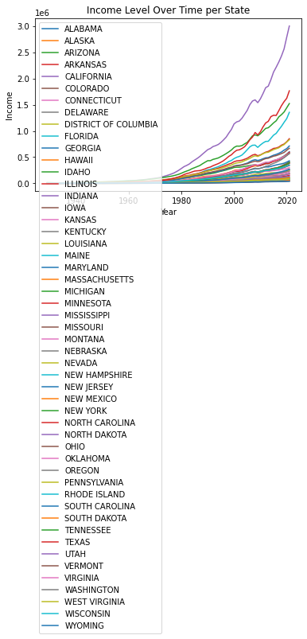

```python
#grabbing names of columns to plot, not including state name
income_cols = list(income_dfT1.columns.values)
income_cols = income_cols[2:53] #grabbing from first state up until regions

income_dfT1.plot(x = 'year', y=income_cols)

plt.legend(income_cols);
plt.title("Income Level Over Time per State")
plt.xlabel('Year')
plt.ylabel('Income')
```

The above plot is just useful to note that income generally increased extremely over time for each state, and it is evident that some states have significantly more average income than others, such as California.

It is important to note that the cost of living is not the same in each state as well.

```python
income_dfT1.set_index('year', inplace=True)
income_dfT1.head()
```

| GeoName year | UNITED STATES | ALABAMA | ALASKA | ARIZONA | ARKANSAS | CALIFORNIA | COLORADO | CONNECTICUT | DELAWARE | DISTRICT OF COLUMBIA | ... | WISCONSIN | WYOMING | NEW ENGLAND | MIDEAST | GREAT LAKES | PLAINS | SOUTHEAST | SOUTHWEST | ROCKY MOUNTAIN | FAR WEST |
| --- | --- | --- | --- | --- | --- | --- | --- | --- | --- | --- | --- | --- | --- | --- | --- | --- | --- | --- | --- | --- | --- |
| 1929 | 85151.0 | 843.2 | NaN | 257.3 | 560.4 | 5495.5 | 635.6 | 1640.5 | 243.4 | 639.3 | ... | 1966.8 | 149.9 | 7122.1 | 27429.4 | 20057.6 | 7500.3 | 9867.4 | 4221.8 | 1597.2 | 7355.1 |
| 1930 | 76394.0 | 697.5 | NaN | 224.7 | 416.5 | 5079.4 | 596.8 | 1494.7 | 205.1 | 641.4 | ... | 1724.7 | 131.6 | 6585.3 | 25575.4 | 17176.9 | 6718.8 | 8480.3 | 3624.0 | 1468.1 | 6765.2 |
| 1931 | 65531.0 | 583.7 | NaN | 184.5 | 381.8 | 4387.5 | 498.5 | 1313.1 | 187.7 | 631.7 | ... | 1402.6 | 109.3 | 5886.4 | 22230.5 | 14355.4 | 5600.5 | 7449.1 | 3054.4 | 1173.7 | 5781.1 |
| 1932 | 50162.0 | 421.9 | NaN | 137.0 | 278.5 | 3441.4 | 380.3 | 1026.9 | 144.9 | 567.9 | ... | 1094.0 | 86.4 | 4714.4 | 17396.5 | 10479.1 | 4225.6 | 5618.7 | 2301.0 | 927.5 | 4499.1 |
| 1933 | 47114.0 | 435.6 | NaN | 131.8 | 283.2 | 3277.3 | 378.4 | 970.3 | 140.4 | 500.2 | ... | 1014.1 | 85.5 | 4411.9 | 16080.9 | 9677.7 | 3765.5 | 5736.6 | 2281.9 | 886.2 | 4273.4 |

5 rows × 60 columns

```python
all_states = states_measles_incidence.columns.unique() #grabbing the names of all the states
```

We wish to explore the relationship between incidence and average income per state.

We can calculate the correlation of the two for each state over all of the years that we have data available for.

```python
correl_income_df = pd.DataFrame(columns = ['Location']) #creating a dataframe of 2 columns
correl_income_df['Location'] = all_states #filling in location with state names

incidences = [states_measles_incidence, states_hepa_incidence, states_mumps_incidence, states_pertussis_incidence, states_polio_incidence, states_rubella_incidence]

meas_corr_data = []
for i in all_states: #calculates the correlation between incidence of measles and average income of the state and appends to an array which we will throw into the dataframe later
  meas_corr_data.append(states_measles_incidence[[i]][i].corr(income_dfT1[[i]][i]))
correl_income_df['Correlation for Measles'] = meas_corr_data

meas_corr_data = []
for i in all_states: #calculates the correlation between incidence of measles and average income of the state and appends to an array which we will throw into the dataframe later
  meas_corr_data.append(states_hepa_incidence[[i]][i].corr(income_dfT1[[i]][i]))
correl_income_df['Correlation for Hepatitis A'] = meas_corr_data

meas_corr_data = []
for i in all_states: #calculates the correlation between incidence of measles and average income of the state and appends to an array which we will throw into the dataframe later
  meas_corr_data.append(states_mumps_incidence[[i]][i].corr(income_dfT1[[i]][i]))
correl_income_df['Correlation for Mumps'] = meas_corr_data

meas_corr_data = []
for i in all_states: #calculates the correlation between incidence of measles and average income of the state and appends to an array which we will throw into the dataframe later
  meas_corr_data.append(states_pertussis_incidence[[i]][i].corr(income_dfT1[[i]][i]))
correl_income_df['Correlation for Pertussis'] = meas_corr_data

meas_corr_data = []
for i in all_states: #calculates the correlation between incidence of measles and average income of the state and appends to an array which we will throw into the dataframe later
  meas_corr_data.append(states_polio_incidence[[i]][i].corr(income_dfT1[[i]][i]))
correl_income_df['Correlation for Polio'] = meas_corr_data

meas_corr_data = []
for i in all_states: #calculates the correlation between incidence of measles and average income of the state and appends to an array which we will throw into the dataframe later
  meas_corr_data.append(states_rubella_incidence[[i]][i].corr(income_dfT1[[i]][i]))
correl_income_df['Correlation for Rubella'] = meas_corr_data

correl_income_df
```

|  | Location | Correlation for Measles | Correlation for Hepatitis A | Correlation for Mumps | Correlation for Pertussis | Correlation for Polio | Correlation for Rubella |
| --- | --- | --- | --- | --- | --- | --- | --- |
| 0 | ALABAMA | -0.438864 | -0.787450 | -0.673812 | -0.619376 | -0.182555 | -0.553569 |
| 1 | ALASKA | -0.504059 | -0.421837 | -0.557576 | -0.223854 | -0.281991 | -0.580474 |
| 2 | ARIZONA | -0.471913 | -0.687155 | -0.526443 | -0.605962 | -0.138901 | -0.372119 |
| 3 | ARKANSAS | -0.374091 | -0.685318 | -0.443986 | -0.603096 | 0.024448 | -0.342586 |
| 4 | CALIFORNIA | -0.491681 | -0.840580 | -0.561661 | -0.494432 | -0.292186 | -0.597785 |
| 5 | COLORADO | -0.473118 | -0.790049 | -0.520779 | -0.477964 | -0.030515 | -0.475452 |
| 6 | CONNECTICUT | -0.494054 | -0.676581 | -0.587232 | -0.566260 | -0.196509 | -0.491188 |
| 7 | DELAWARE | -0.352530 | -0.691063 | -0.706025 | -0.448722 | 0.016508 | -0.387056 |
| 8 | DISTRICT OF COLUMBIA | -0.430254 | -0.381729 | -0.315241 | -0.562689 | -0.055079 | -0.272922 |
| 9 | FLORIDA | -0.393899 | -0.701293 | -0.611818 | -0.532889 | 0.012449 | -0.530016 |
| 10 | GEORGIA | -0.320447 | -0.688778 | -0.263598 | -0.559281 | -0.015368 | -0.351515 |
| 11 | HAWAII | -0.444390 | -0.669737 | -0.517535 | -0.203510 | -0.416792 | -0.426629 |
| 12 | IDAHO | -0.460630 | -0.692686 | -0.566743 | -0.471422 | 0.077795 | -0.487007 |
| 13 | ILLINOIS | -0.471243 | -0.758112 | -0.707377 | -0.510833 | -0.119096 | -0.629050 |
| 14 | INDIANA | -0.471012 | -0.784077 | -0.626504 | -0.644863 | -0.023369 | -0.595665 |
| 15 | IOWA | -0.418800 | -0.603993 | -0.603113 | -0.464908 | 0.149623 | -0.573497 |
| 16 | KANSAS | -0.466032 | -0.741988 | -0.662507 | -0.538337 | 0.096425 | -0.429905 |
| 17 | KENTUCKY | -0.439927 | -0.750518 | -0.641025 | -0.635103 | 0.041686 | -0.559005 |
| 18 | LOUISIANA | -0.447005 | -0.810822 | -0.254834 | -0.463114 | 0.056014 | -0.485844 |
| 19 | MAINE | -0.479206 | -0.516104 | -0.567805 | -0.633887 | -0.046865 | -0.556266 |
| 20 | MARYLAND | -0.383021 | -0.663977 | -0.563129 | -0.560587 | -0.059396 | -0.474399 |
| 21 | MASSACHUSETTS | -0.553791 | -0.489817 | -0.459569 | -0.559990 | -0.107367 | -0.560347 |
| 22 | MICHIGAN | -0.500868 | -0.737273 | -0.675314 | -0.609570 | -0.119926 | -0.729918 |
| 23 | MINNESOTA | -0.373499 | -0.697321 | -0.530679 | -0.444325 | -0.070244 | -0.499605 |
| 24 | MISSISSIPPI | -0.377433 | -0.732160 | -0.561017 | -0.385160 | 0.055086 | -0.373902 |
| 25 | MISSOURI | -0.439282 | -0.600504 | -0.655783 | -0.521782 | 0.021800 | -0.447154 |
| 26 | MONTANA | -0.500560 | -0.726915 | -0.627714 | -0.438677 | 0.012123 | -0.584399 |
| 27 | NEBRASKA | -0.398446 | -0.537230 | -0.632497 | -0.498075 | 0.176869 | -0.289057 |
| 28 | NEVADA | -0.312422 | -0.669026 | -0.402603 | -0.305455 | 0.116253 | -0.503912 |
| 29 | NEW HAMPSHIRE | -0.384313 | -0.542423 | -0.553658 | -0.561887 | 0.138748 | -0.474458 |
| 30 | NEW JERSEY | -0.519256 | -0.699206 | -0.600998 | -0.593741 | -0.213640 | -0.563064 |
| 31 | NEW MEXICO | -0.452374 | -0.796322 | -0.514237 | -0.517054 | -0.087182 | -0.526129 |
| 32 | NEW YORK | -0.575878 | -0.654657 | -0.635314 | -0.550308 | -0.229062 | -0.525775 |
| 33 | NORTH CAROLINA | -0.316167 | -0.606512 | -0.338804 | -0.457097 | -0.043573 | -0.249987 |
| 34 | NORTH DAKOTA | -0.433816 | -0.499573 | -0.555261 | -0.477584 | 0.070357 | -0.664824 |
| 35 | OHIO | -0.500542 | -0.804153 | -0.703410 | -0.555504 | -0.090723 | -0.687021 |
| 36 | OKLAHOMA | -0.422502 | -0.475569 | -0.528256 | -0.584851 | -0.033737 | -0.382634 |
| 37 | OREGON | -0.523861 | -0.796372 | -0.553439 | -0.599129 | 0.101379 | -0.675984 |
| 38 | PENNSYLVANIA | -0.490885 | -0.650329 | -0.602147 | -0.572429 | -0.132532 | -0.438337 |
| 39 | RHODE ISLAND | -0.394296 | -0.617608 | -0.605285 | -0.621437 | 0.111882 | -0.334214 |
| 40 | SOUTH CAROLINA | -0.392597 | -0.645628 | -0.478741 | -0.499401 | -0.039939 | -0.537443 |
| 41 | SOUTH DAKOTA | -0.265881 | -0.321733 | -0.391740 | -0.422224 | 0.151902 | 0.120758 |
| 42 | TENNESSEE | -0.398904 | -0.701850 | -0.613782 | -0.597027 | 0.003533 | -0.582133 |
| 43 | TEXAS | -0.452337 | -0.842644 | -0.603819 | -0.575867 | 0.044653 | -0.408034 |
| 44 | UTAH | -0.353990 | -0.652629 | -0.518282 | -0.423923 | 0.116972 | -0.612660 |
| 45 | VERMONT | -0.401079 | -0.493054 | -0.474270 | -0.595264 | -0.091076 | -0.390664 |
| 46 | VIRGINIA | -0.473576 | -0.611603 | -0.616531 | -0.568281 | -0.071741 | -0.546190 |
| 47 | WASHINGTON | -0.518176 | -0.715003 | -0.589229 | -0.436118 | -0.179919 | -0.477765 |
| 48 | WEST VIRGINIA | -0.513411 | -0.737397 | -0.782945 | -0.668567 | 0.002412 | -0.677053 |
| 49 | WISCONSIN | -0.547927 | -0.723717 | -0.628660 | -0.543277 | 0.078701 | -0.739234 |
| 50 | WYOMING | -0.391032 | -0.619877 | -0.521698 | -0.547756 | 0.161935 | -0.331384 |

This makes sense because this is saying that for a higher income, the chances of contracting measles is less. Vice versa, for a lower income, the chances of contracting measles is higher. This does not establish causality, but it certainly displays an expected relationship!

Now we can compute some stats about our table.

```python
print('Max correlation for measles: ', correl_income_df['Location'].iloc[correl_income_df['Correlation for Measles'].idxmax()])
print('Min correlation for measles: ', correl_income_df['Location'].iloc[correl_income_df['Correlation for Measles'].idxmin()])
print('Avg correlation for measles: ', correl_income_df['Correlation for Measles'].mean())
```

```
Max correlation for measles:  SOUTH DAKOTA
Min correlation for measles:  NEW YORK
Avg correlation for measles:  -0.4393191688736428
```

We note that we know we cannot make strong claims on this data because income also varies between state based on average living costs.

In addition, we recognize it would have been better to have data for income level of each person who got sick since this income set is just the average income of the state including people who aren't sick. This is just to explore a relationship between overall state wealth and illness.

We can compute these stats for the other diseases too.

## Predictive Modeling Plan

### Model Idea 1

Our first idea for a predictive model is to create a hypothetical situation and predict the chances that someone in a particular state would contract a certain disease in a couple of years after.

For instance, we could say, "Imagine you are living in Louisiana in 1936, and you want to know the chances of you catching Measles in 1952."

The independent variables would be the year, state, disease, and income level and the dependent variable would be the probability that this person will contract the disease at hand.

In terms of the methodology to go about this, we can train a k-nearest neighbors regression model to predict the probability for contracting the disease for different values of k. We can calculate the training and validation mean absolute error of each model. We would get the validation error by using cross-validation. We can plot these errors as a function of k to determine which is the optimal k to use in order to get our final predicted value.

### Model Idea 2

Our second idea for a predictive model is to be the reverse of model idea 1. For example, the question would be "Imagine you are sick with Measles in 1936. What are your likely characteristics?" So the result would be "You are most likely in Louisiana with an income of $700."

The independent variable would be the year, disease, and the fact that you are sick, and the dependent variables would be the state and income.

In terms of the methodology, because we know we are sick, we would require more transformations in the datasets. The incidence rate would have to be on a scale of 0 to 1 to sho probability. We can again train a k-nearest neighbors regression model to predict the probability for contracting the disease for different values of k. We can calculate the training and validation mean absolute error of each model. We would get the validation error by using cross-validation. We can plot these errors as a function of k to determine which is the optimal k to use in order to get our final predicted value.

```python
%%shell

jupyter nbconvert --to html "/content/drive/My Drive/cmps3160/finalProject/Final_Project.ipynb"
```

```
[NbConvertApp] Converting notebook /content/drive/My Drive/cmps3160/finalProject/Final_Project.ipynb to html
[NbConvertApp] Writing 325999 bytes to /content/drive/My Drive/cmps3160/finalProject/Final_Project.html
```